# Project 6 - Recommendation Systems-Copy4

```python
import pandas as pd
import numpy as np
import matplotlib.pyplot as plt
import scipy as sp
import seaborn as sns
```

```python
t1=pd.read_csv("phone_user_review_file_1.csv",low_memory=False)
```

```python
t1.head()
```

|  | phone_url | date | lang | country | source | domain | score | score_max | extract | author | product |
| --- | --- | --- | --- | --- | --- | --- | --- | --- | --- | --- | --- |
| 0 | /cellphones/samsung-galaxy-s8/ | 5/2/2017 | en | us | Verizon Wireless | verizonwireless.com | 10.0 | 10.0 | As a diehard Samsung fan who has had every Sam... | CarolAnn35 | Samsung Galaxy S8 |
| 1 | /cellphones/samsung-galaxy-s8/ | 4/28/2017 | en | us | Phone Arena | phonearena.com | 10.0 | 10.0 | Love the phone. the phone is sleek and smooth ... | james0923 | Samsung Galaxy S8 |
| 2 | /cellphones/samsung-galaxy-s8/ | 5/4/2017 | en | us | Amazon | amazon.com | 6.0 | 10.0 | Adequate feel. Nice heft. Processor's still sl... | R. Craig | Samsung Galaxy S8 (64GB) G950U 5.8" 4G LTE Unl... |
| 3 | /cellphones/samsung-galaxy-s8/ | 5/2/2017 | en | us | Samsung | samsung.com | 9.2 | 10.0 | Never disappointed. One of the reasons I've be... | Buster2020 | Samsung Galaxy S8 64GB (AT&T) |
| 4 | /cellphones/samsung-galaxy-s8/ | 5/11/2017 | en | us | Verizon Wireless | verizonwireless.com | 4.0 | 10.0 | I've now found that i'm in a group of people t... | S Ate Mine | Samsung Galaxy S8 |

```python
t1.shape
```

```
(374910, 11)
```

```python
t2=pd.read_csv("phone_user_review_file_2.csv",low_memory=False)
```

```python
t2.shape
```

```
(114925, 11)
```

```python
t3=pd.read_csv("phone_user_review_file_3.csv",low_memory=False)
```

```python
t3.shape
```

```
(312961, 11)
```

```python
t4=pd.read_csv("phone_user_review_file_4.csv",low_memory=False)
```

```python
t4.shape
```

```
(98284, 11)
```

```python
t5=pd.read_csv("phone_user_review_file_5.csv",low_memory=False)
```

```python
t5.shape
```

```
(350216, 11)
```

```python
t6=pd.read_csv("phone_user_review_file_6.csv",low_memory=False)
```

```python
t6.shape
```

```
(163837, 11)
```

```python
t6.shape[0]+t5.shape[0]+t4.shape[0]+t3.shape[0]+t2.shape[0]+t1.shape[0]
```

```
1415133
```

```python
data=pd.concat([t1,t2,t3,t4,t5,t6],ignore_index=True)
```

```python
data.describe()
```

|  | score | score_max |
| --- | --- | --- |
| count | 1.351644e+06 | 1351644.0 |
| mean | 8.007060e+00 | 10.0 |
| std | 2.616121e+00 | 0.0 |
| min | 2.000000e-01 | 10.0 |
| 25% | 7.200000e+00 | 10.0 |
| 50% | 9.200000e+00 | 10.0 |
| 75% | 1.000000e+01 | 10.0 |
| max | 1.000000e+01 | 10.0 |

Score_max seems to be an irrelevant feature and hence we can drop it.

```python
data.columns
```

```
Index(['phone_url', 'date', 'lang', 'country', 'source', 'domain', 'score',
       'score_max', 'extract', 'author', 'product'],
      dtype='object')
```

```python
data.head()
```

|  | phone_url | date | lang | country | source | domain | score | score_max | extract | author | product |
| --- | --- | --- | --- | --- | --- | --- | --- | --- | --- | --- | --- |
| 0 | /cellphones/samsung-galaxy-s8/ | 5/2/2017 | en | us | Verizon Wireless | verizonwireless.com | 10.0 | 10.0 | As a diehard Samsung fan who has had every Sam... | CarolAnn35 | Samsung Galaxy S8 |
| 1 | /cellphones/samsung-galaxy-s8/ | 4/28/2017 | en | us | Phone Arena | phonearena.com | 10.0 | 10.0 | Love the phone. the phone is sleek and smooth ... | james0923 | Samsung Galaxy S8 |
| 2 | /cellphones/samsung-galaxy-s8/ | 5/4/2017 | en | us | Amazon | amazon.com | 6.0 | 10.0 | Adequate feel. Nice heft. Processor's still sl... | R. Craig | Samsung Galaxy S8 (64GB) G950U 5.8" 4G LTE Unl... |
| 3 | /cellphones/samsung-galaxy-s8/ | 5/2/2017 | en | us | Samsung | samsung.com | 9.2 | 10.0 | Never disappointed. One of the reasons I've be... | Buster2020 | Samsung Galaxy S8 64GB (AT&T) |
| 4 | /cellphones/samsung-galaxy-s8/ | 5/11/2017 | en | us | Verizon Wireless | verizonwireless.com | 4.0 | 10.0 | I've now found that i'm in a group of people t... | S Ate Mine | Samsung Galaxy S8 |

phone_url is also an irrelevant feature so we can go ahead and drop it.

```python
data["lang"].is_unique
```

```
False
```

```python
data["lang"].value_counts()
```

```
en    554746
ru    207443
de    176600
it    116120
es     99739
fr     95080
pt     67155
nl     38375
tr     28359
sv     17149
fi      6953
cs      2533
no      1918
he      1370
pl       493
da       418
hu       346
id       271
ja        33
zh        19
ar        12
ko         1
Name: lang, dtype: int64
```

```python
round(data["score"],1) # Rounding of the decimal places.
```

```
0          10.0
1          10.0
2           6.0
3           9.2
4           4.0
           ...
1415128     2.0
1415129    10.0
1415130     2.0
1415131     8.0
1415132     2.0
Name: score, Length: 1415133, dtype: float64
```

```python
data[data.isna()].sum()
```

```
phone_url      0
date           0
lang           0
country        0
source         0
domain         0
score        0.0
score_max    0.0
extract        0
author         0
product        0
dtype: object
```

```python
data["domain"].value_counts() #Notice once invalid character here.
```

```
amazon.com          214776
amazon.de           132720
market.yandex.ru    123066
amazon.in           112880
amazon.it            89533
                     ...
megagadgets.nl           1
staples.nl               1
verdicts.co.uk           1
skapiec.pl               1
officedepot.com          1
Name: domain, Length: 384, dtype: int64
```

```python
data.dtypes
```

```
phone_url     object
date          object
lang          object
country       object
source        object
domain        object
score        float64
score_max    float64
extract       object
author        object
product       object
dtype: object
```

```python
for each in data.columns:
    print(each," : ",data[each].isna().sum())
```

```
phone_url  :  0
date  :  0
lang  :  0
country  :  0
source  :  0
domain  :  0
score  :  63489
score_max  :  63489
extract  :  19361
author  :  63202
product  :  1
```

**Some Observations Worth Noting**

If score is not given, then that particular entry is completely useless. We can't substitute it with zero, because that would be doing injustice to the product, and some genuine reviews. On top of that the actual review written in words might be completley speaking otherwise. There are other methods which can be used, like analyzing the words used and the user profile to understand if the rating is missing because of some data entry problem or is it some kind of incomplete or fake review that is unsuitable for analysis. But, here we don't have access to NLP kind of analysis, hence we don't opt for it.

If author field is not given, it might be irrelevant for a few types of recommendation systems, but for something like apriori or user-user collaborative recommendations it becomes important to identify. Moreoever it becomes really important to understand if the missing entry of the "author" is repeated elsewhere. If it is supposedly repeated, meaning that user has bought multiple items and hence, that would cause loss of valuable information regarding the user behaviour.

If extract is not given, then that particular entry might be useless if we are going to any kind of recommendation system other than that of popular recommendation settings. So, we have to take a decision to drop these appropriate entries when we are going for content based recommendation systems.

There are some expected types of entries into the particular column like for example, "source" is expected to be purely a string, but there might be some other entries other than alphabets and some serious characters. We can eliminate them. Country is strictly a string value, but we should check the same, and so that can be used to correct some entries with approximate entries with most matching ones.

We can create new columns out of old ones, like date here, which will help us in further analysis.

Two entries, Source and the website corresponding to that source both are redundant, hence we can simply drop the source column and retain domain column.

```python
data[data.duplicated()]
```

|  | phone_url | date | lang | country | source | domain | score | score_max | extract | author | product |
| --- | --- | --- | --- | --- | --- | --- | --- | --- | --- | --- | --- |
| 342 | /cellphones/samsung-galaxy-s8/ | 4/26/2017 | nl | nl | Coolblue | coolblue.nl | 9.6 | 10.0 | Ik vind het tot nu toe een heel erg aangenaam ... | Stefanie Hinneman | Samsung Galaxy S8 Zwart |
| 343 | /cellphones/samsung-galaxy-s8/ | 4/26/2017 | nl | nl | Coolblue | coolblue.nl | 9.6 | 10.0 | Ik vind het tot nu toe een heel erg aangenaam ... | Stefanie Hinneman | Samsung Galaxy S8 Zwart |
| 371 | /cellphones/samsung-galaxy-s8/ | 4/25/2017 | nl | nl | Coolblue | coolblue.nl | 9.6 | 10.0 | Tot nu toe in de eerste dagen weinig tot geen ... | Robin Winckens | Samsung Galaxy S8 Zwart |
| 452 | /cellphones/samsung-galaxy-s8/ | 4/25/2017 | nl | nl | Coolblue | coolblue.nl | 10.0 | 10.0 | Wat een huge scherm! | B Yapar | Samsung Galaxy S8 Zwart |
| 3718 | /cellphones/samsung-galaxy-s6-edgeplus/ | 10/4/2015 | en | us | Amazon | amazon.com | 10.0 | 10.0 | For readers, my opinions on this device (ATT 3... | FrozenCloud | Samsung Galaxy S6 Edge+, Black 64GB (Verizon W... |
| ... | ... | ... | ... | ... | ... | ... | ... | ... | ... | ... | ... |
| 1398132 | /cellphones/nokia-8850/ | 8/31/2010 | ru | ru | Yandex | market.yandex.ru | 10.0 | 10.0 | Просто отличный телефон, который приятно лежит... | NaN | Nokia 8850 |
| 1398134 | /cellphones/nokia-8850/ | 6/25/2010 | ru | ru | Yandex | market.yandex.ru | 10.0 | 10.0 | За свои деньги, 1000 долларов которые он когда... | NaN | Nokia 8850 |
| 1410207 | /cellphones/samsung-sgh-600/ | 4/30/2015 | tr | tr | Cepworld | cepworld.com | NaN | NaN | varsa satan 05312614607 | muhsin | Samsung (936) SGH-600 |
| 1411460 | /cellphones/philips-genie-2000/ | 8/20/2000 | it | it | Ciao | ciao.it | 8.0 | 10.0 | Il Genie e' un buon telefono, scorrimente del ... | tonyblack | Philips Genie 2000 |
| 1412950 | /cellphones/motorola-m3888/ | 12/11/2000 | it | it | Ciao | ciao.it | 10.0 | 10.0 | E' un telefonino qualitativamente ottimo sopra... | NaN | Motorola M3888 |

6412 rows × 11 columns

There seems to be two kinds of duplicate entries here, one in which it might mean that review given on one domain might be different than another. Here we are blindly assuming that user doesn't have the same username across the domains, hence two users with same name but different domains will be treated as different users, even though the extract is exactly the same and product is also exactly the same.

The other review is the same user, same domain same product but either different rating or different extract. In that case, we have to consider the most recent extract and most recent rating. If there is a collision in terms of date, we have to consider the lowest rating (if there is a rating difference) or choose extract with most number of words (assuming that the user didn't write crappy reviews and the extract actually describes in detail the working of the project.)

# Proposition for Data Cleaning

Step 1. Drop any entries within the rows where the product under review is not mentioned. No matter what the URL is, which can change all the time, the product have to be there for us to take any decision. So, we will try to extract information about the missing product name from the URL. (there seems to be only one such entry here so no problems regarding that).

Step 2. Convert the datetime kind of format and check it out. If there are any exceptions while conversions they can be appropriately handled.

Step 3. Eliminate Duplicate entries by taking taking author names and trying to find out if they belong to the same domain, if so if they wrote multiple reviews for the same product. If so, check which review is the latest and take that review as the honest one and drop the other. If there is a date conflict, go for the rating, and choose the lowest rating. If the rating is in conflict too, then go for highest number of words in the extract column and choose for that particular entry and drop the others. We are going to exclusively deal with index vlaues here, so we have to be careful.

**Step 1** : Checking for product columns missing values.

```python
#Checking for Product NaN columns
temp=data["product"][data["product"].isna()].index
data.loc[temp]
```

|  | phone_url | date | lang | country | source | domain | score | score_max | extract | author | product |
| --- | --- | --- | --- | --- | --- | --- | --- | --- | --- | --- | --- |
| 802795 | /cellphones/samsung-galaxy-s-iii/ | 1/22/2014 | de | de | Amazon | amazon.de | 10.0 | 10.0 | Bestes Smartphone was ich bisher hatte :) öafk... | NaN | NaN |

```python
temp_url=data.loc[temp]["phone_url"]
```

```python
for each_item in data["phone_url"]:
    if type(each_item)!=str:
        print(each_item)
#Looks like there is no columns which is not recognized as a string.
```

```python
temp_url
```

```
802795    /cellphones/samsung-galaxy-s-iii/
Name: phone_url, dtype: object
```

```python
import re

same_url_list=[]
for each_ind in data.index:
    k=re.search('/*/samsung-galaxy-s-iii/',data["phone_url"][each_ind])
    if k:
        same_url_list.append(each_ind)
```

```python
data.loc[same_url_list].head()
```

|  | phone_url | date | lang | country | source | domain | score | score_max | extract | author | product |
| --- | --- | --- | --- | --- | --- | --- | --- | --- | --- | --- | --- |
| 794264 | /cellphones/samsung-galaxy-s-iii/ | 10/6/2015 | en | us | CNET | reviews.cnet.com | 2.0 | 10.0 | After only six months, I'm having software iss... | rstidyman | Samsung Galaxy S III T-Mobile |
| 794265 | /cellphones/samsung-galaxy-s-iii/ | 5/6/2015 | en | us | Phone Arena | phonearena.com | 9.0 | 10.0 | This phone was great at the time of release, g... | chanpion01 | Samsung Galaxy S III |
| 794266 | /cellphones/samsung-galaxy-s-iii/ | 9/9/2016 | en | us | Samsung | samsung.com | 9.2 | 10.0 | Samsung products are awesome! Great quality. L... | Mnstrek4u | Samsung Galaxy S III 16GB (Straight Talk) |
| 794267 | /cellphones/samsung-galaxy-s-iii/ | 5/7/2017 | en | us | Amazon | amazon.com | 10.0 | 10.0 | I love this phone. It does everything I need i... | Marisa Spagnuolo | Samsung Galaxy S3, Red (AT&T) |
| 794268 | /cellphones/samsung-galaxy-s-iii/ | 2/17/2016 | en | us | Newegg | newegg.com | 8.0 | 10.0 | this is probably the best phone you can get if... | Anonymous | SAMSUNG Galaxy S III SGH-i747 Blue 3G 4G LTE D... |

```python
data.loc[same_url_list].count()
```

```
phone_url    17093
date         17093
lang         17093
country      17093
source       17093
domain       17093
score        14463
score_max    14463
extract      17002
author       16882
product      17092
dtype: int64
```

Looks like we can substitute one of the enties into the product column since it looks perfectly fine except the author missing column.

```python
#Now let us replace the product column of that particular entry in the dataframe with approrpoiate mechanism.

data.loc[temp]["product"]=data.loc[same_url_list].head().iloc[1]["product"]
```

We can generalize this whole thing and go ahead, but let us restrict ourselves to this particular case where I randomly picked the product name. **Assuming that there are no vairations for within the product.** . Hopefully that will stay the way, even though we have grabbed it from different domain and different user.

**Step 2** : Converting to the Date-Time Timeline for analysis.

```python
#Converting the Date columns to a much more feasilbe format.
data["date"]=pd.to_datetime(data["date"], infer_datetime_format=True)
```

```python
data["date"]
```

```
0         2017-05-02
1         2017-04-28
2         2017-05-04
3         2017-05-02
4         2017-05-11
             ...
1415128   2000-05-12
1415129   2000-05-11
1415130   2000-05-04
1415131   2000-05-01
1415132   2000-04-25
Name: date, Length: 1415133, dtype: datetime64[ns]
```

```python
data["date"].loc[1415128].month
#Small demonstration of the effect.
```

```
5
```

```python
duplicate_entries=data[data.duplicated(subset=["author","product"],keep=False)].index
data.loc[duplicate_entries]
```

|  | phone_url | date | lang | country | source | domain | score | score_max | extract | author | product |
| --- | --- | --- | --- | --- | --- | --- | --- | --- | --- | --- | --- |
| 66 | /cellphones/samsung-galaxy-s8/ | 2017-05-06 | en | gb | Very | very.co.uk | 10.0 | 10.0 | This phone is amazing screen isnt as big as th... | James | Samsung Galaxy S8, 64Gb - Orchid Grey |
| 106 | /cellphones/samsung-galaxy-s8/ | 2017-05-05 | en | gb | Very | very.co.uk | 10.0 | 10.0 | Pre ordered and received early. Amazing phone ... | James | Samsung Galaxy S8, 64Gb - Orchid Grey |
| 244 | /cellphones/samsung-galaxy-s8/ | 2017-05-06 | nl | nl | Coolblue | coolblue.nl | 10.0 | 10.0 | In een woord geweldig!!!! | John van der Made | Samsung Galaxy S8 Zwart |
| 270 | /cellphones/samsung-galaxy-s8/ | 2017-05-04 | cs | cz | CZC | czc.cz | 10.0 | 10.0 | Rozhodně nejlepší smartphone pro rok 2017, vyt... | NaN | Samsung Galaxy S8, 64GB, černá |
| 278 | /cellphones/samsung-galaxy-s8/ | 2017-05-03 | nl | nl | Coolblue | coolblue.nl | 10.0 | 10.0 | Geen woorden voor. ZoÃ¶loog geweldig. | John van der Made | Samsung Galaxy S8 Zwart |
| ... | ... | ... | ... | ... | ... | ... | ... | ... | ... | ... | ... |
| 1414907 | /cellphones/ericsson-gf-768/ | 2000-07-12 | en | gb | Dooyoo | dooyoo.co.uk | 2.0 | 10.0 | The Telephone of new generation. Stylish, grac... | anonym | Ericsson GF 768 |
| 1415002 | /cellphones/ericsson-pf-768/ | 2000-01-28 | de | de | Dooyoo | dooyoo.de | 6.0 | 10.0 | Aufmerksamkeit erregt das PF 768 mit seinen kr... | NaN | Ericsson PF768 |
| 1415004 | /cellphones/ericsson-pf-768/ | 2000-01-13 | de | de | Dooyoo | dooyoo.de | 8.0 | 10.0 | Aufmerksamkeit erregt das PF 768 mit seinen kr... | NaN | Ericsson PF768 |
| 1415130 | /cellphones/alcatel-ot-club_1187/ | 2000-05-04 | de | de | Ciao | ciao.de | 2.0 | 10.0 | Jetzt hat wohl Alcatell gedacht ,sie machen wa... | michaelawr | Alcatel Club Plus Handy |
| 1415132 | /cellphones/alcatel-ot-club_1187/ | 2000-04-25 | de | de | Ciao | ciao.de | 2.0 | 10.0 | Was sich Alkatel hier wieder ausgedacht hat,sc... | michaelawr | Alcatel Club Plus Handy |

270729 rows × 11 columns

Method to eliminate duplicate entries is not taken here. It is discussed in more detail, later on.

```python
data.shape[0]
```

```
1415133
```

```python
# Setting random state for seeding as given.
np.random.seed(seed=612)
random_indices=np.random.choice(data.index,size=1000000,replace=False)
#random_indices=data["date"].sample(n=1000000,random_state=612)
```

```python
random_indices #having a look at the random indices generated by numpy from the given data.
```

```
array([1381066,  159224,  166941, ...,  296497, 1113808,  395582],
      dtype=int64)
```

```python
pd.Series(random_indices).is_unique
```

```
True
```

```python
data_stage3=data.loc[random_indices].copy()
```

```python
data_stage3.shape
```

```
(1000000, 11)
```

```python
data_stage3["score_max"].value_counts() #Looks like all of them have a maximum score of 10, so it is irrelevant feature for now.
```

```
10.0    955222
Name: score_max, dtype: int64
```

```python
data_stage3.drop(["source","phone_url","score_max"],axis=1,inplace=True) #dropping irrelevant features for now.
```

To identify most rated features or the phones with most rating, we should have it such that the phones or entries with no rating can't be considered i.e. missing rating can be and should be eliminated and they can't be be imputed with anything else, because that would beat the purpose of it all. It pushes unncessary entries into the recommendations.

```python
data_stage3.shape
```

```
(1000000, 8)
```

```python
data_stage3[data_stage3["score"].isna()]
```

|  | date | lang | country | domain | score | extract | author | product |
| --- | --- | --- | --- | --- | --- | --- | --- | --- |
| 553182 | 2015-03-27 | pt | br | cissamagazine.com.br | NaN | celular Otimo produto celular nokia lumia 530 ... | ALEX kraus | Smartphone Nokia Lumia 530 Dual Desbloqueado B... |
| 401466 | 2015-09-11 | pt | br | cissamagazine.com.br | NaN | Ascend P1000 Produto surpreendente, superou mi... | André Barros Duarte | Smartphone Huawei Ascend P7 L10 Desbloqueado P... |
| 1263020 | 2009-01-12 | en | us | reviewstream.com | NaN | I got this phone several weeks ago and so far ... | E.S Nobody | Sony Ericsson W760a |
| 933124 | 2011-11-07 | fr | fr | avis.sfr.fr | NaN | Sa fluidité est incroyable !!! L'écran Super A... | Allan31 | SAMSUNG Galaxy SII (S2) |
| 1292905 | 2008-03-17 | it | it | tecnozoom.it | NaN | Il miglio pocket pc della sua categoria, dall'... | fnuzzo | Htc X7500 - Advantage |
| ... | ... | ... | ... | ... | ... | ... | ... | ... |
| 417235 | 2015-10-24 | pt | br | cissamagazine.com.br | NaN | otimo aparelho nota 10 muito bom site confiáve... | eliton vieira | Smartphone Sony Xperia Z3 Compact D5833 Desblo... |
| 624723 | 2013-11-05 | ru | ru | svyaznoy.ru | NaN | Можно закачать 4 или 5 приложений, потом даже ... | Дмитрий | Sony Xperia C (черный) |
| 492031 | 2016-03-03 | pt | br | cissamagazine.com.br | NaN | otimo otima chegou no prazo certo e é um otimo... | luana capistana ribeiro dos santos | Smartphone Samsung Galaxy J2 Duos TV J200BT De... |
| 585372 | 2015-06-20 | pt | br | cissamagazine.com.br | NaN | Aparelho excelente! A partir de várias análise... | Cassiano Endlich | Smartphone LG G3 Beat Dual D724 Desbloqueado P... |
| 1246797 | 2011-07-04 | tr | tr | tiklayaz.com | NaN | dış görünüş olarak çok güzel gerçekten hepiniz... | anneme | Nokia E61 Cep Telefonu |

44778 rows × 8 columns

```python
print("Entries that doesn't have a specified Score is ", data_stage3["score"][data_stage3['score'].notna()].count()) # This is completely useless.
```

```
Entries that doesn't have a specified Score is  955222
```

```python
data_stage3=data_stage3[data_stage3['score'].notna()] #Eliminating non entry to the scores columns considering only entry columns.

data_stage3["score"]=data_stage3["score"].round().astype("int64") # Converting them to proper type after rounding up.

data_stage3["product"][data_stage3["score"]==data_stage3["score"].max()] # Checking for the phones with maximum rating.
```

```
159224                                                 LG G5
290110     Tech Armor Galaxy Note 4 Screen Protector, Tec...
416939     Sony Xperia Z3 Compact Smartphone, Display 4,6...
1105330    LG Cosmos VN250 Black No Contract No Data Veri...
1163761                                             LG Lotus
                                 ...
236519     Doro Liberto 820 SIM-Free Smartphone - Black/S...
463516     Samsung Galaxy S5 Mini G800h 16gb Hspa+ Unlock...
275060          Smartphone Samsung Galaxy Gran Prime SM-G531
1113808                                BlackBerry Curve 8520
395582     Motorola Moto E 4G 2nd Generation SIM-Free Sma...
Name: product, Length: 470385, dtype: object
```

These are the top phones that have got the maximum rating. But, that alone is not the criteria for phone recommendations here. For being a top recommendation being popular, it should have two characteristics :

1. Be top rated most of the times i.e. mean rating for the phone should be highest of all.
2. It should be highest occurring of all i.e. it should be extremely frequent within the count.

**Please Note** :

Here two phones with similar features but a little different variations (e.g. different color), are considered as different products. In other words, it is assumed that those variations (colors) within the features are assumed to be totally different features in themselves. It requires huge amount of processing power and also some deep analytics of NLP to deal with similarity between two different phone version. We will try to attempt them but for now, we will consider those products are different products.

```python
value_count_products=data_stage3["product"].value_counts()
```

```python
value_count_products.keys() # Having a breif look at the most sold phones, and total variety of phones.
```

```
Index(['Lenovo Vibe K4 Note (White,16GB)', 'Lenovo Vibe K4 Note (Black, 16GB)',
       'OnePlus 3 (Graphite, 64 GB)', 'OnePlus 3 (Soft Gold, 64 GB)',
       'Huawei P8lite zwart / 16 GB', 'Lenovo Vibe K5 (Gold, VoLTE update)',
       'Samsung Galaxy S6 zwart / 32 GB',
       'Lenovo Vibe K5 (Grey, VoLTE update)', 'Nokia 5800 XpressMusic',
       'Nokia N95',
       ...
       'Motorola V220 Black - Camera Phone - Mp3 Ringtones - Virgin PAYG',
       'Sony Xperia Z1 Compact Zwart', 'SAMSUNG Galaxy S Duos - hvit',
       'Nokia Samsung U800 Soul B Silver Sim Free Unlocked Mobile Phone',
       'Samsung SM-A310F 16GB 4G - smartphones (Single SIM, Android, NanoSIM, GSM, WCDMA, LTE)',
       'ASUS Zenfone3 Deluxe 5.7" Unlocked Smartphone, 64GB, Android 6.0',
       'Gigabyte GSmart Sierra S1', 'Nokia C6-00 - Black Smartphone',
       'Samsung Champ 3.5G',
       'Huawei Honor 8 32GB Unlocked GSM 4G LTE Quad-Core Android Phone with 12MP Dual Lens Camera - Pearl White'],
      dtype='object', length=51740)
```

```python
data_stage3_score_grouping=data_stage3.groupby("score")
```

```python
data_stage3_score_grouping.indices #Checking out the groupings of which phones have beeen rated how.
```

```
{0: array([ 14860,  69068, 144927, 207396, 276633, 281053, 291182, 304468,
        391635, 421697, 427883, 490790, 523362, 556173, 561197, 608447,
        640812, 655640, 668322, 670701, 691802, 721475, 739333, 768359,
        795031, 802091, 804810, 812752, 837896, 940852, 948955],
       dtype=int64),
 1: array([   280,   1254,   1407, ..., 954922, 954934, 955059], dtype=int64),
 2: array([     9,     11,     12, ..., 955176, 955196, 955204], dtype=int64),
 3: array([     0,    522,   1002, ..., 953785, 953914, 955187], dtype=int64),
 4: array([     5,     14,     29, ..., 955209, 955212, 955214], dtype=int64),
 5: array([   416,    515,    523, ..., 953417, 953811, 953955], dtype=int64),
 6: array([     2,      8,     10, ..., 955188, 955216, 955219], dtype=int64),
 7: array([    33,    110,    246, ..., 954943, 955210, 955215], dtype=int64),
 8: array([     3,      6,      7, ..., 955202, 955208, 955211], dtype=int64),
 9: array([    49,    137,    161, ..., 955181, 955200, 955217], dtype=int64),
 10: array([     1,      4,     13, ..., 955218, 955220, 955221], dtype=int64)}
```

Noting from the above the indices of the particular phones whose indices and the particular ratings are given. Now, let us create another column where the mean score for that product is attributed. But before that we have to group the phones by their type.

```python
data_stage3_product_grouping=data_stage3.groupby("product") # We will come back to these again in a new form later on.
```

It is to be noted that phones that are sold should be sold by a minimum amount of the total phones sold to be even eligible for consideration of the top recommendations. Hence, we will eliminate all the phones that are sold just one or two in quantity and consider the ratings for the most sold phones and then sort those phones in accordance to their mean rating.

I have set here threshold to be 10% of the most sold phone's frequency (the total sales to be cut off and hence has been noted down.) from the very strong assumption that most frequently occurring product is the product that is most sold, which might be extremely wrong assumption.( I myself haven't rated a lot of items I bought).

```python
threshold_phones=value_count_products[0]/10 # This threshold value can be changed.
ratings_phones={}
######################################################################
for each_phone in value_count_products.keys():
    #print(each_phone)
    if value_count_products[each_phone]<threshold_phones:
        #print(value_count_products[each_phone])
        #print(each_phone)
        continue
    else:
        #print(each_phone)
        #print(data_stage3_product_grouping.get_group(each_phone)["score"].mean())
        ratings_phones.update({each_phone: data_stage3_product_grouping.get_group(each_phone)["score"].mean()})
####################################################################
```

```python
 # Sorting the values so that recommendations come up automatically.
####################################################################
# Function that sorts the dictionary based on the values
####################################################################
def sort_dict_values(given_dict,reverse=True):
    sorted_values=sorted(given_dict.values(),reverse=reverse)
    sorted_ratings={}
    for i in sorted_values:
        for k in given_dict.keys():
            if given_dict[k] == i:
                sorted_ratings[k]=given_dict[k]
                break
    return sorted_ratings
###############################################################
# End of funtion
###############################################################
sorted_ratings_phones = sort_dict_values(ratings_phones)
```

The above cell is copied from the internet at address given below : https://stackabuse.com/how-to-sort-dictionary-by-value-in-python/

```python
###########################################################################
# Gives top phones based on the recommendations and the threshold as set before.
###########################################################################
def give_top_phones(sorted_ratings_phones,how_many_phones=10,min_rating=None):
    phones=[]
    if min_rating!=None:
        for each_item in sorted_ratings_phones:
            if sorted_ratings_phones[each_item]>=min_rating:
                phones.append([each_item,sorted_ratings_phones[each_item]])
        #print(phones)
        phones=pd.DataFrame(phones,columns=["Product","Avg_Rating"])
    else:
        phones=pd.DataFrame(phones,columns=["Product","Avg_Rating"])
    return phones[:how_many_phones]#pd.DataFrame(phones,columns=["Phone","Rating"])
###########################################################################
# End of function
###########################################################################
```

```python
#sorted_ratings_phones
```

```python
give_top_phones(sorted_ratings_phones,how_many_phones=30,min_rating=8) # You can change the rating and the number of phones here.
```

|  | Product | Avg_Rating |
| --- | --- | --- |
| 0 | Apple iPhone 7 4,7" 32 GB | 9.787879 |
| 1 | Samsung Galaxy S7 edge Smartphone, 13,9 cm (5,... | 9.596120 |
| 2 | Samsung Galaxy S7 Smartphone, 12,9 cm (5,1 Zol... | 9.538670 |
| 3 | Sim Free Motorola Moto G 4th Generation Mobile... | 9.524752 |
| 4 | Samsung Galaxy A3 (2016) - A310F Smartphone, 1... | 9.522863 |
| 5 | Lenovo Motorola Moto G Smartphone, Display HD ... | 9.511013 |
| 6 | Samsung Galaxy S7 edge 32GB (AT&T) | 9.489733 |
| 7 | Samsung Galaxy S6 edge+ 32GB (T-Mobile) | 9.471748 |
| 8 | Samsung Galaxy S7 edge 32GB (T-Mobile) | 9.464548 |
| 9 | Lenovo Motorola Moto G Smartphone, 4,5 pollici... | 9.428300 |
| 10 | Samsung Galaxy S6 edge+ 32GB (Verizon) | 9.422680 |
| 11 | Samsung Galaxy S7 32GB (AT&T) | 9.411095 |
| 12 | Samsung Galaxy S7 32GB (T-Mobile) | 9.410796 |
| 13 | Samsung Galaxy S7 32GB (Verizon) | 9.396325 |
| 14 | Samsung Galaxy S7 edge 32GB (Verizon) | 9.395440 |
| 15 | Samsung Galaxy S7 edge 32GB (Sprint) | 9.393053 |
| 16 | Apple iPhone 5s 16GB (серебристый) | 9.383764 |
| 17 | Samsung Galaxy S7 32GB (Sprint) | 9.347403 |
| 18 | Samsung Galaxy S6 edge 32GB (T-Mobile) | 9.286070 |
| 19 | Samsung Galaxy S6 32GB (Sprint) | 9.285061 |
| 20 | Samsung Galaxy S6 32GB (Verizon) | 9.263158 |
| 21 | Samsung Galaxy S6 32GB (T-Mobile) | 9.262948 |
| 22 | Samsung Galaxy S6 active 32GB (AT&T) | 9.252475 |
| 23 | Samsung Galaxy S5 16GB (Verizon) | 9.233333 |
| 24 | Samsung Galaxy S5 16GB (AT&T) | 9.205805 |
| 25 | Huawei P9 Lite Smartphone, LTE, Display 5.2'' ... | 9.195706 |
| 26 | Smartphone Samsung Galaxy S4 Mini GT-I9192 | 9.162996 |
| 27 | Lenovo Motorola Moto G LTE Smartphone, Display... | 9.151242 |
| 28 | Samsung Galaxy S III | 9.113402 |
| 29 | Smartphone Motorola Moto X 2ª Geração XT1097 3... | 9.108959 |

This is the complete recommendation based on average rating (mean rating) for devices based on certain threshold conditions.

```python
data["author"].value_counts(dropna=False)[:15]
```

```
Amazon Customer    76978
NaN                63202
Cliente Amazon     19304
e-bit               8663
Client d'Amazon     7716
Amazon Kunde        4750
Anonymous           2750
einer Kundin        2610
einem Kunden        1898
unknown             1738
Anonymous           1461
Александр           1071
David               1016
Сергей               904
Zákazník             898
Name: author, dtype: int64
```

It is completely impractical for a person to rate those many reviews i.e. 76978. It is clear that those particular customers failed to provide their names. They can be the same author or different author. There are hundreds of possibilities here too. Within it, there are places where the author's name is not mentioned (NaN) values are there implying that those customers simply refused to mention their names.

```python
data_stage4=data_stage3.copy()
from sklearn.metrics.pairwise import cosine_similarity
from sklearn.feature_extraction.text import CountVectorizer

#############################################################################
data_stage4['product']=data_stage4['product'].str.replace("(",",")
data_stage4['product']=data_stage4['product'].str.replace(")",",")
data_stage4['product']=data_stage4['product'].str.replace(" ","")
#data_stage4['product'] = data_stage4['product'].map(lambda x: x.split(','))

data_stage4["product"] # We will keep this aside for future analysis.
```

```
1381066                                     MM-A700/SPH-A700
159224                                                  LGG5
166941                            MicrosoftLumia6403GDualSim
340422                      SAMSUNGGalaxyS5,CopperGold,16GB,
290110     TechArmorGalaxyNote4ScreenProtector,TechArmorH...
                                 ...
904632                                           LGOptimusL3
275060               SmartphoneSamsungGalaxyGranPrimeSM-G531
296497     HTCOneA9FactoryUnlockedSmartphone,32GB4GLTE5-I...
1113808                                  BlackBerryCurve8520
395582     MotorolaMotoE4G2ndGenerationSIM-FreeSmartphone...
Name: product, Length: 955222, dtype: object
```

```python
#from rake_nltk import Rake
```

```python
#Checking for keywords and most important features.
#for index, row in data_stage4.iterrows():
#    features = row['product']
#    r = Rake()
#    r.extract_keywords_from_text(features)
#    key_words_dict_scores = r.get_word_degrees()
```

```python
count_df=pd.DataFrame(sorted_ratings_phones,index=range(len(sorted_ratings_phones)))


count_input=[]
###################################################################
for entry in count_df.columns.str.split(","):
    for each_entry in entry:
        count_input.append(each_entry)
###################################################################
```

```python
pd.Series(count_input)
```

```
0                           Apple iPhone 7 4
1                                   7" 32 GB
2          Samsung Galaxy S7 edge Smartphone
3                                         13
4                                    9 cm (5
                       ...
403                                    16GB)
404    Lenovo Used Lenovo Zuk Z1 (Space Grey
405                                    64GB)
406                     Lenovo Zuk Z1 (White
407                             Cyanogen OS)
Length: 408, dtype: object
```

```python
pd.Series(count_input).value_counts()[:10] # this shows the most important features
```

```
 16GB)               13
 16 GB)               6
 Fotocamera 13 MP     5
 8 GB Speicher        4
 LTE (4G)             4
 32GB)                4
 Nero [Italia]        3
 Bianco [Italia]      3
 LTE                  3
 Memoria 8 GB         3
dtype: int64
```

**Observations** : 16 GB phones seem to be very popular and required of the important features here. Also, phones with Fotocamera (might be other language used here) might be the most important feature, but along with it 4G seem to be most important feature here.

But it needs a little more detail into what are the proper details on the most important features. It needs count vectorizer for each

```python
count = CountVectorizer()
count_matrix = count.fit_transform(count_df)
```

```python
count_matrix
```

```
<211x373 sparse matrix of type '<class 'numpy.int64'>'
	with 1334 stored elements in Compressed Sparse Row format>
```

```python
count_matrix=count_matrix.todense()
```

```python
pd.DataFrame(sorted_ratings_phones,index=range(len(sorted_ratings_phones))).columns
```

```
Index(['Apple iPhone 7 4,7" 32 GB',
       'Samsung Galaxy S7 edge Smartphone, 13,9 cm (5,5 Zoll) Display, LTE (4G)',
       'Samsung Galaxy S7 Smartphone, 12,9 cm (5,1 Zoll) Display, LTE (4G)',
       'Sim Free Motorola Moto G 4th Generation Mobile Phone - Black',
       'Samsung Galaxy A3 (2016) - A310F Smartphone, 12 cm (4,7 Zoll) Display, LTE (4G)',
       'Lenovo Motorola Moto G Smartphone, Display HD 4,5", Processore Qualcomm, Memoria 8 GB, MicroSIM, Android 4.4 OS, Fotocamera da 5 MP, Nero [Germania]',
       'Samsung Galaxy S7 edge 32GB (AT&T)',
       'Samsung Galaxy S6 edge+ 32GB (T-Mobile)',
       'Samsung Galaxy S7 edge 32GB (T-Mobile)',
       'Lenovo Motorola Moto G Smartphone, 4,5 pollici display HD, processore Qualcomm, memoria 16GB, MicroSIM, Android 4.3 OS, fotocamera da 5 MP, Nero [Germania]',
       ...
       'Lenovo Vibe K5 (Grey, VoLTE update)',
       'Lenovo Phab 2 Plus Smartphone (Grey, JBL earphones)',
       'Samsung Galaxy Centura Android Prepaid Phone (TracFone)',
       'Lenovo A6000 (White, 8GB)', 'YU Yuphoria YU5010A (Black+Silver)',
       'Motorola Moto G, 4th Gen (White, 2 GB, 16 GB)',
       'Apple iPhone 5 A1428 Factory Unlocked Cellphone, 16GB, Black',
       'Apple iPhone SE (Gold, 16GB)',
       'Lenovo Used Lenovo Zuk Z1 (Space Grey, 64GB)',
       'Lenovo Zuk Z1 (White, Cyanogen OS)'],
      dtype='object', length=211)
```

```python
sorted_features=sort_dict_values(count.vocabulary_,reverse=True)
```

```python
sorted_features
```

```
{'серебристый': 372,
 'zwart': 371,
 'zuk': 370,
 'zte': 369,
 'zoll': 368,
 'zenfone': 367,
 'ze550kl': 366,
 'zc550kl': 365,
 'z3': 364,
 'z1': 363,
 'yuphoria': 362,
 'yu5010a': 361,
 'yu': 360,
 'xt1575': 359,
 'xt1097': 358,
 'xpressmusic': 357,
 'xperia': 356,
 'xl': 355,
 'xiaomi': 354,
 'x3': 353,
 'x2': 352,
 'x10': 351,
 'with': 350,
 'wit': 349,
 'windows': 348,
 'wildfire': 347,
 'wi': 346,
 'white': 345,
 'weiß': 344,
 'wave': 343,
 'warranty': 342,
 'walkman': 341,
 'w595': 340,
 'w580i': 339,
 'volte': 338,
 'volt': 337,
 'vivo': 336,
 'vivaz': 335,
 'virgin': 334,
 'video': 333,
```

[output cut: 318 more lines]

```
 '21': 14,
 '2016': 13,
 '20': 12,
 '16gb': 11,
 '16': 10,
 '14': 9,
 '13': 8,
 '128gb': 7,
 '12': 6,
 '11': 5,
 '1020': 4,
 '10': 3,
 '04g': 2,
 '03': 1,
 '00': 0}
```

```python
how_many_features=20
########################################################################
#Gives us top features based on the no of times they were mentioend based on popularity.
#######################################################################

def give_top_features(sorted_features,how_many_features=10):
    phones=[]
    phones=pd.DataFrame(pd.Series(sorted_features),columns=["Popularity"])
    return phones[:how_many_features]#pd.DataFrame(phones,columns=["Phone","Rating"])
########################################################################
#End of function
########################################################################
```

```python
give_top_features(sorted_features,how_many_features=how_many_features)
```

|  | Popularity |
| --- | --- |
| серебристый | 372 |
| zwart | 371 |
| zuk | 370 |
| zte | 369 |
| zoll | 368 |
| zenfone | 367 |
| ze550kl | 366 |
| zc550kl | 365 |
| z3 | 364 |
| z1 | 363 |
| yuphoria | 362 |
| yu5010a | 361 |
| yu | 360 |
| xt1575 | 359 |
| xt1097 | 358 |
| xpressmusic | 357 |
| xperia | 356 |
| xl | 355 |
| xiaomi | 354 |
| x3 | 353 |

We will go for a more detailed look later on with apriori based recommendation for better analysis.

It is also to note that some of them are brands, some of them are just plain features, and some of them are phone model. Here the assumption and distinction between them is not made at all.

```python
#count2 = CountVectorizer()
#count_matrix2 = count2.fit_transform(data_stage4["product"].values)

#sorted_features2=sort_dict_values(count2.vocabulary_,reverse=True)

#give_top_features(sorted_features2,how_many_features=50)
```

A product should be mentioned atleast 50 times for it to be eligible to be separated according to the given question. From those ones, the things that are to be rated atleast 50 times should be separated out. We have already eliminated entries where the ratings not given entries are dropped. So, first let us create the index of items which have been mentioned at least 50 times.

```python
data_stage5_org=data_stage3.copy()
```

```python
data_stage5=data_stage3.groupby("product") # Frist grouping by product, and eliminating those that aren't mentioned 50 times
```

```python
#this produces indices for the entries where the corresponding product has atleast 50 ratings, after we have taken that
#there are atleast 50 entries for a given product.
k=[] # Contains the products which have mentions atleast 50 times, and the places where they are mentioned.
#########################################################################
for each in data_stage5.indices:
    #print(len(data_stage5.indices[each]))
    if len(data_stage5.indices[each])>50:
        #print("Yes Entered")
        k.append(list(data_stage5.indices[each]))
#########################################################################

##########################################################################
l=[]
for i in range(1,len(k)):
    r=k[i]
    for each in r:
        l.append(each)
#########################################################################
```

```python
data_stage5=data_stage3.iloc[l]
```

```python
data_stage6=data_stage5.groupby("author") # Second grouping by author, and eliminating entries that aren't by authors that haven't written atleast 50 entries.
```

```python
#this produces indices for the entries where the corresponding author has atleast 50 ratings, after we have taken that
#there are atleast 50 entries for a given product.
k=[]
#####################################################################
for each in data_stage6.indices:
    if len(data_stage6.indices[each])>50:
        k.append(data_stage6.indices[each])
#####################################################################

##########################################################################
l=[]
for i in range(1,len(k)):
    r=k[i]
    for each in r:
        l.append(each)
#########################################################################

data_stage7=data_stage5.iloc[l]
```

**Some Observations about the Data Collection**

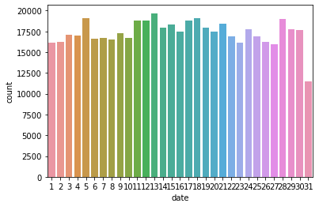

```python
sns.countplot(data_stage5.date.dt.day)
```

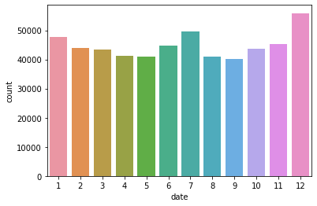

```python
sns.countplot(data_stage5.date.dt.month)
```

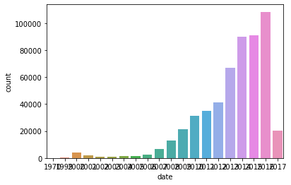

```python
sns.countplot(data_stage5.date.dt.year)
```

**Observations** There is an interesting pattern here where most of the entries are from the more recent times. It is undertandable because of growth and popularity of domain diversity and online sales. It is to be noted that there are a lot of repurcussions on this. The most serious one being that the maximum number of products any single person can buy and rate will fall down drastically because of this higher concentration of distribution along one particular side implying that there might be a lot of fake entries into this. This needs to be further studied and explored, as we do later and might serve as a strong reason to favour a few decisions that are revealed later on.

# Further Data Analysis

```python
data_stage7
```

|  | date | lang | country | domain | score | extract | author | product |
| --- | --- | --- | --- | --- | --- | --- | --- | --- |
| 853045 | 2014-01-09 | ru | ru | catalog.onliner.by | 10 | ?????????????????? 5 ?????????????? 4 ????????... | ???????? | Apple iPhone 5 (16Gb) |
| 853744 | 2013-06-07 | ru | ru | catalog.onliner.by | 10 | ???? ???????? ?????? ?????????? ???????????? ?... | ???????? | Apple iPhone 5 (16Gb) |
| 854184 | 2013-02-22 | ru | ru | catalog.onliner.by | 10 | ?????????????????????? ?????????? ????????????... | ???????? | Apple iPhone 5 (16Gb) |
| 853325 | 2013-11-29 | ru | ru | catalog.onliner.by | 10 | ?????????????????? ?????????????????? 3 ??????... | ???????? | Apple iPhone 5 (16Gb) |
| 855495 | 2012-10-06 | ru | ru | catalog.onliner.by | 2 | ?????�?????? ?? ?????????????? ?? ????????????... | ???????? | Apple iPhone 5 (16Gb) |
| ... | ... | ... | ... | ... | ... | ... | ... | ... |
| 475884 | 2014-03-31 | ru | ru | svyaznoy.ru | 10 | NaN | Юрий | Sony Xperia Z1 Compact (черный) |
| 475823 | 2014-03-31 | ru | ru | svyaznoy.ru | 10 | Лучшее, что на данный момент существует на рын... | Юрий | Sony Xperia Z1 Compact (черный) |
| 617913 | 2013-08-16 | ru | ru | svyaznoy.ru | 7 | Трубой доволен, одному экземпляру в сентябре г... | Юрий | Sony Xperia ZR (черный) |
| 545201 | 2014-01-14 | ru | ru | ulmart.ru | 10 | это просто маенький кусочек технологий, которы... | Юрий | Смартфон Apple iPhone 5S 16Gb Space Gray ME432... |
| 305107 | 2015-10-14 | ru | ru | mobiguru.ru | 10 | Удачное вложение денег. Смартфон привлекателен... | Юрий | Сотовый телефон Asus ZenFone 2 |

85003 rows × 8 columns

```python
data_stage7["author"].value_counts()[:20] #these are the top 20 customers with most number of reviews.
```

```
Amazon Customer    40220
Cliente Amazon      6873
e-bit               4954
Client d'Amazon     2562
Amazon Kunde        2124
einer Kundin        1852
einem Kunden        1310
Anonymous           1001
Anonymous            649
Александр            424
Дмитрий              370
Сергей               363
Marco                356
David                346
Andrea               323
Alex                 306
Алексей              296
Андрей               289
unknown              275
Daniel               268
Name: author, dtype: int64
```

```python
# Training Apriori on the dataset
#from apyori import apriori
#rules = apriori(data_stage7["product"], min_support = 0.20, min_confidence = 0.2, min_lift = 3, min_length = 2)
#results = list(rules)
```

```python
#for item in results:
#    pair = item[0]
#    items = [x for x in pair]
#    print(items[0])
```

```python
data_stage7.shape # Total number of entries in the dataframe, to make things clear in the very beginning.
```

```
(85003, 8)
```

We are now going to check if there are duplicated entries for the same author, same product. If they are then we check for the date and take the latest ones, and drop the older ones. Because the latest entry can be considered as the most valued entry and the previous ones can be abandoned. Below cells demonstrate how it is checked. We go ahead with a function to do the same for all the authors and products.

**step by step approach** :

1. First identify the duplicate entries in author and product column together, indicating that entries are most likely updates.
2. Check if the particular user has most recent entry for the same product. Take that most recent entry as the genuine entry of that particular user.
3. Check if their extract is the same or changed, if the score is same or changed (over time). If score changed to something or extract changed to something that is not valid, go back with the valid entries.
4. Make a list of all duplicate entries, and assert that all the entries need to be dropped. Then search for a reason and mechanism for each type of entry not to be dropped. If they are found to be valid and not to be dropped, then modify the entry, or do some kind of modifications in the original dataframe and then later drop them from the list of entries that are to be dropped.
5. Finally create a matrix of ratings and users, and then let the models and algorithms work on it.

```python
temp_index=data_stage7[data_stage7.duplicated(subset=["author","product"],keep=False)]
```

```python
temp_index
```

|  | date | lang | country | domain | score | extract | author | product |
| --- | --- | --- | --- | --- | --- | --- | --- | --- |
| 853045 | 2014-01-09 | ru | ru | catalog.onliner.by | 10 | ?????????????????? 5 ?????????????? 4 ????????... | ???????? | Apple iPhone 5 (16Gb) |
| 853744 | 2013-06-07 | ru | ru | catalog.onliner.by | 10 | ???? ???????? ?????? ?????????? ???????????? ?... | ???????? | Apple iPhone 5 (16Gb) |
| 854184 | 2013-02-22 | ru | ru | catalog.onliner.by | 10 | ?????????????????????? ?????????? ????????????... | ???????? | Apple iPhone 5 (16Gb) |
| 853325 | 2013-11-29 | ru | ru | catalog.onliner.by | 10 | ?????????????????? ?????????????????? 3 ??????... | ???????? | Apple iPhone 5 (16Gb) |
| 855495 | 2012-10-06 | ru | ru | catalog.onliner.by | 2 | ?????�?????? ?? ?????????????? ?? ????????????... | ???????? | Apple iPhone 5 (16Gb) |
| ... | ... | ... | ... | ... | ... | ... | ... | ... |
| 475622 | 2014-03-31 | ru | ru | svyaznoy.ru | 10 | Купил телефон год назад, ни разу не пожалел и ... | Юрий | Sony Xperia Z1 Compact (розовый) |
| 476180 | 2014-03-31 | ru | ru | svyaznoy.ru | 10 | Купил телефон год назад, ни разу не пожалел и ... | Юрий | Sony Xperia Z1 Compact (черный) |
| 476286 | 2014-03-31 | ru | ru | svyaznoy.ru | 10 | До него был Sony J, это был страх и ужас, туп ... | Юрий | Sony Xperia Z1 Compact (черный) |
| 475884 | 2014-03-31 | ru | ru | svyaznoy.ru | 10 | NaN | Юрий | Sony Xperia Z1 Compact (черный) |
| 475823 | 2014-03-31 | ru | ru | svyaznoy.ru | 10 | Лучшее, что на данный момент существует на рын... | Юрий | Sony Xperia Z1 Compact (черный) |

71042 rows × 8 columns

```python
temp_index.shape # These many duplicate entries are there. These are huge in number out of the 85760 entries that are originally there.
```

```
(71042, 8)
```

Let us take a small example and check out how this works out.

```python
temp2=temp_index.groupby("author").get_group("Юрий")
temp2 #Particular author having duplicate entries in either author column or product column
```

|  | date | lang | country | domain | score | extract | author | product |
| --- | --- | --- | --- | --- | --- | --- | --- | --- |
| 544162 | 2014-01-15 | ru | ru | svyaznoy.ru | 10 | "Нужно брать!". Берите восстановленный, разниц... | Юрий | Apple iPhone 5s 16GB (серебристый) |
| 543472 | 2014-01-15 | ru | ru | svyaznoy.ru | 10 | iPhone 5s, смартфон для реальной, повседневной... | Юрий | Apple iPhone 5s 16GB (серебристый) |
| 543176 | 2014-01-15 | ru | ru | svyaznoy.ru | 10 | Понты Если понты - это желание пользоваться ка... | Юрий | Apple iPhone 5s 16GB (серебристый) |
| 543911 | 2014-01-15 | ru | ru | svyaznoy.ru | 6 | Ни разу не слышал от пользователей продукции A... | Юрий | Apple iPhone 5s 16GB (серебристый) |
| 544107 | 2014-01-15 | ru | ru | svyaznoy.ru | 7 | В итоге, можно сказать что данный смартфон сто... | Юрий | Apple iPhone 5s 16GB (серебристый) |
| 544203 | 2014-01-15 | ru | ru | svyaznoy.ru | 6 | Ни разу не слышал от пользователей продукции A... | Юрий | Apple iPhone 5s 16GB (серый космос) |
| 544618 | 2014-01-15 | ru | ru | svyaznoy.ru | 7 | В итоге, можно сказать что данный смартфон сто... | Юрий | Apple iPhone 5s 16GB (серый космос) |
| 544184 | 2014-01-15 | ru | ru | svyaznoy.ru | 6 | Ни разу не слышал от пользователей продукции A... | Юрий | Apple iPhone 5s 16GB (серый космос) |
| 933880 | 2014-01-22 | ru | ru | catalog.onliner.by | 10 | Сколько раз меня выручал этот смартфон (я студ... | Юрий | LG P500 Optimus One |
| 934339 | 2011-10-11 | ru | ru | catalog.onliner.by | 10 | Телефон стоит своих денег! Сенсорный экран, ск... | Юрий | LG P500 Optimus One |
| 957917 | 2011-10-26 | ru | ua | rozetka.com.ua | 10 | Сегодня забрал)) для папы, качественная сборка... | Юрий | Nokia 101 Premium Black |
| 957670 | 2012-06-17 | ru | ua | rozetka.com.ua | 10 | купляв батькам, хороший телефон за таки гроші | Юрий | Nokia 101 Premium Black |
| 1189825 | 2010-07-17 | ru | ru | catalog.onliner.by | 8 | Сразу замечу, что рынок наполнен китайскими по... | Юрий | Nokia 6700 classic |
| 1190337 | 2009-02-10 | ru | ru | catalog.onliner.by | 10 | Пользуюсь телефоном уже 2 дня. За это время те... | Юрий | Nokia 6700 classic |
| 788269 | 2014-01-16 | ru | ua | rozetka.com.ua | 10 | Пользуюсь уже почти год, вывод: качество сборк... | Юрий | Nokia Lumia 920 White |
| 788446 | 2013-11-27 | ru | ua | rozetka.com.ua | 8 | . | Юрий | Nokia Lumia 920 White |
| 788933 | 2013-07-03 | ru | ua | rozetka.com.ua | 10 | Улет полный, купил и балдею ))), до нее юзал Л... | Юрий | Nokia Lumia 920 White |
| 275674 | 2016-12-12 | ru | ru | samsung.com | 10 | Хороший вид удобные кнопки Выкл и громкости вп... | Юрий | Samsung Galaxy A7 |
| 275663 | 2016-12-12 | ru | ru | samsung.com | 6 | отвратительный телефон , покупал как оптимальн... | Юрий | Samsung Galaxy A7 |
| 697472 | 2013-08-11 | ru | ru | svyaznoy.ru | 7 | Очень мощный телефон.Но денег своих все же не ... | Юрий | Samsung Galaxy S4 GT-I9500 16GB (белый) |
| 697504 | 2013-08-11 | ru | ru | svyaznoy.ru | 10 | Телефон шикарный, никакие айфоны и люмии рядом... | Юрий | Samsung Galaxy S4 GT-I9500 16GB (белый) |
| 697533 | 2013-08-11 | ru | ru | svyaznoy.ru | 10 | Хочу предостереч потенциальных покупателей что... | Юрий | Samsung Galaxy S4 GT-I9500 16GB (белый) |
| 697902 | 2013-08-07 | ru | ru | svyaznoy.ru | 7 | Очень мощный телефон.Но денег своих все же не ... | Юрий | Samsung Galaxy S4 GT-I9500 16GB (черный) |
| 697934 | 2013-08-07 | ru | ru | svyaznoy.ru | 10 | Телефон шикарный, никакие айфоны и люмии рядом... | Юрий | Samsung Galaxy S4 GT-I9500 16GB (черный) |
| 697964 | 2013-08-07 | ru | ru | svyaznoy.ru | 10 | Хочу предостереч потенциальных покупателей что... | Юрий | Samsung Galaxy S4 GT-I9500 16GB (черный) |
| 643567 | 2013-01-05 | ru | ru | svyaznoy.ru | 9 | Samsung Galaxy Note II - заметное отличие!!! И... | Юрий | Samsung N7100 Galaxy Note II 16GB (серый) |
| 643612 | 2013-01-05 | ru | ru | svyaznoy.ru | 10 | Брал как замену двум устройствам: Galaxy S III... | Юрий | Samsung N7100 Galaxy Note II 16GB (серый) |
| 1219254 | 2012-06-14 | ru | ru | catalog.onliner.by | 10 | Приобрёл данный девайс 2 недели назад. Доволен... | Юрий | Samsung i9100 Galaxy S II (16Gb) |
| 1219774 | 2012-01-05 | ru | ru | catalog.onliner.by | 10 | Купил сей аппарат уже больше месяца назад и ка... | Юрий | Samsung i9100 Galaxy S II (16Gb) |
| 624925 | 2013-11-05 | ru | ru | svyaznoy.ru | 9 | хожу с ним уже больше года, телефон всегда под... | Юрий | Sony Xperia C (белый) |
| 624953 | 2013-11-05 | ru | ru | svyaznoy.ru | 9 | Мой самый первый смартфон, пользовался им 2 го... | Юрий | Sony Xperia C (белый) |
| 624599 | 2013-11-05 | ru | ru | svyaznoy.ru | 9 | хожу с ним уже больше года, телефон всегда под... | Юрий | Sony Xperia C (фиолетовый) |
| 624518 | 2013-11-05 | ru | ru | svyaznoy.ru | 8 | Вообще не работает интернет от СИМки. Хотя ант... | Юрий | Sony Xperia C (фиолетовый) |
| 624714 | 2013-11-05 | ru | ru | svyaznoy.ru | 9 | Мой самый первый смартфон, пользовался им 2 го... | Юрий | Sony Xperia C (черный) |
| 625088 | 2013-11-05 | ru | ru | svyaznoy.ru | 8 | Вообще не работает интернет от СИМки. Хотя ант... | Юрий | Sony Xperia C (черный) |
| 624689 | 2013-11-05 | ru | ru | svyaznoy.ru | 9 | хожу с ним уже больше года, телефон всегда под... | Юрий | Sony Xperia C (черный) |
| 736608 | 2013-08-08 | ru | ru | svyaznoy.ru | 8 | Через некоторое время перестал выходить в инте... | Юрий | Sony Xperia SP (красный) |
| 736618 | 2013-08-08 | ru | ru | svyaznoy.ru | 10 | Ну вот, а теперь скажу следующее. SP красивый ... | Юрий | Sony Xperia SP (красный) |
| 674916 | 2013-06-22 | ru | ru | svyaznoy.ru | 10 | По мне так отличный смартфон. Про достоинства ... | Юрий | Sony Xperia Z (белый) |
| 674389 | 2013-06-22 | ru | ru | svyaznoy.ru | 7 | Это не первый смарт у меня скажу больше только... | Юрий | Sony Xperia Z (белый) |
| 674810 | 2013-06-22 | ru | ru | svyaznoy.ru | 9 | Долго выбирал между нексус 5 и сони.Хоть убей ... | Юрий | Sony Xperia Z (белый) |
| 674533 | 2013-06-22 | ru | ru | svyaznoy.ru | 7 | Это не первый смарт у меня скажу больше только... | Юрий | Sony Xperia Z (черный) |
| 675169 | 2013-06-22 | ru | ru | svyaznoy.ru | 9 | Класс | Юрий | Sony Xperia Z (черный) |
| 675059 | 2013-06-22 | ru | ru | svyaznoy.ru | 10 | По мне так отличный смартфон. Про достоинства ... | Юрий | Sony Xperia Z (черный) |
| 674971 | 2013-06-22 | ru | ru | svyaznoy.ru | 9 | Долго выбирал между нексус 5 и сони.Хоть убей ... | Юрий | Sony Xperia Z (черный) |
| 475896 | 2014-03-31 | ru | ru | svyaznoy.ru | 10 | NaN | Юрий | Sony Xperia Z1 Compact (белый) |
| 476293 | 2014-03-31 | ru | ru | svyaznoy.ru | 10 | До него был Sony J, это был страх и ужас, туп ... | Юрий | Sony Xperia Z1 Compact (белый) |
| 476207 | 2014-03-31 | ru | ru | svyaznoy.ru | 10 | До него был Sony J, это был страх и ужас, туп ... | Юрий | Sony Xperia Z1 Compact (лайм) |
| 476102 | 2014-03-31 | ru | ru | svyaznoy.ru | 10 | Купил телефон год назад, ни разу не пожалел и ... | Юрий | Sony Xperia Z1 Compact (лайм) |
| 475778 | 2014-03-31 | ru | ru | svyaznoy.ru | 10 | Лучшее, что на данный момент существует на рын... | Юрий | Sony Xperia Z1 Compact (лайм) |
| 475802 | 2014-03-31 | ru | ru | svyaznoy.ru | 10 | NaN | Юрий | Sony Xperia Z1 Compact (лайм) |
| 475492 | 2014-03-31 | ru | ru | svyaznoy.ru | 10 | Лучшее, что на данный момент существует на рын... | Юрий | Sony Xperia Z1 Compact (розовый) |
| 475524 | 2014-03-31 | ru | ru | svyaznoy.ru | 10 | NaN | Юрий | Sony Xperia Z1 Compact (розовый) |
| 475649 | 2014-03-31 | ru | ru | svyaznoy.ru | 10 | До него был Sony J, это был страх и ужас, туп ... | Юрий | Sony Xperia Z1 Compact (розовый) |
| 475622 | 2014-03-31 | ru | ru | svyaznoy.ru | 10 | Купил телефон год назад, ни разу не пожалел и ... | Юрий | Sony Xperia Z1 Compact (розовый) |
| 476180 | 2014-03-31 | ru | ru | svyaznoy.ru | 10 | Купил телефон год назад, ни разу не пожалел и ... | Юрий | Sony Xperia Z1 Compact (черный) |
| 476286 | 2014-03-31 | ru | ru | svyaznoy.ru | 10 | До него был Sony J, это был страх и ужас, туп ... | Юрий | Sony Xperia Z1 Compact (черный) |
| 475884 | 2014-03-31 | ru | ru | svyaznoy.ru | 10 | NaN | Юрий | Sony Xperia Z1 Compact (черный) |
| 475823 | 2014-03-31 | ru | ru | svyaznoy.ru | 10 | Лучшее, что на данный момент существует на рын... | Юрий | Sony Xperia Z1 Compact (черный) |

```python
#For that particular user, creating a grouping by product. Ideally it should be only one product per user, but if it isn't, that means
# either its updated entries or mistaken multiple entries.
temp3 = temp2.groupby("product").get_group("Sony Xperia Z1 Compact (лайм)")
temp3
#Notice here that we need to consider only one of the entries below i.e. the latest one for consideration because the
# user has updated his score and also his extract. Only the latest entries have to be considered.
```

|  | date | lang | country | domain | score | extract | author | product |
| --- | --- | --- | --- | --- | --- | --- | --- | --- |
| 476207 | 2014-03-31 | ru | ru | svyaznoy.ru | 10 | До него был Sony J, это был страх и ужас, туп ... | Юрий | Sony Xperia Z1 Compact (лайм) |
| 476102 | 2014-03-31 | ru | ru | svyaznoy.ru | 10 | Купил телефон год назад, ни разу не пожалел и ... | Юрий | Sony Xperia Z1 Compact (лайм) |
| 475778 | 2014-03-31 | ru | ru | svyaznoy.ru | 10 | Лучшее, что на данный момент существует на рын... | Юрий | Sony Xperia Z1 Compact (лайм) |
| 475802 | 2014-03-31 | ru | ru | svyaznoy.ru | 10 | NaN | Юрий | Sony Xperia Z1 Compact (лайм) |

```python
temp3.date.sort_values(ascending=False).index[0] # This is the index value that needs to be retained among all the index values.
```

```
476207
```

Since we have done the above, we can be clear as to what our approach should be. We have to fix everything above into a funcion and then subject it to all possible users.

But before that we need to know a few things about the original dataframe.

```python
print("The Number of Unique Products",len(data_stage7["product"].unique()))# Notice how many actual unique products are there.

print("The Number of Unique Authors",len(data_stage7["author"].unique())) # Notice how many actual unique users are there.

print("The Number of Unique Extracts",len(data_stage7["extract"].unique())) # This is indicates the total number of unique reviews given by the users.

#Now, if we take an approximate, we can get an idea of how many reviews a user has posted on an average for each different product.
print("The Average Number of reviews per Author",len(data_stage7["product"].unique())/len(data_stage7["author"].unique()))
```

```
The Number of Unique Products 3517
The Number of Unique Authors 231
The Number of Unique Extracts 81211
The Average Number of reviews per Author 15.225108225108226
```

Considering, the number of unique extracts some of them by the same user and some by different users, some by the users who declined to give their author name, some by the same user rating the same product at a later time i.e. editing their product review. This is just never ending saga and it is suggestive that a proper username should be made must for any reviewer in future to make our model work good.

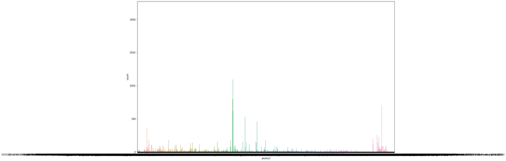

```python
plt.figure(figsize=(20,12))
sns.countplot(data_stage7["product"])
plt.show()
```

**Very important Conclusion** Note here that, since we have got that at an average a user buys 15 products. In that line of thought, it is highly likely that the product is never bought more than once. If such is the case then the number of counts of each product shouldn't be more than the total number of customers. That means no product should be counted more than the total number of authors viz. 231. But, that seems to be not the case seriously. That means the products were rated multiple times and most probably at different times.

[figure not shown]

```python
plt.figure(figsize=(20,12))
sns.jointplot(x=data_stage7["product"],y=data_stage7["author"],kind="hist")
plt.show()
```

```python
print("Total entries within the dataframe : ",len(data_stage7.index))

print("If the index is unique for the dataframe : ",data_stage7.index.is_unique)

print("The minimum entry in the index column of the data :",data_stage7.index.min())

print("The maximum entry in the index column of the data :",data_stage7.index.max())
```

```
Total entries within the dataframe :  85003
If the index is unique for the dataframe :  True
The minimum entry in the index column of the data : 272
The maximum entry in the index column of the data : 1414288
```

This gives us a clear idea that number in index is not exactly of the number, it is just an entry in the original dataframe before we sampled 1000000 datapoints from it, or before even taking the borderline i.e. atleast 50 entry criteria.

```python
data_stage7.iloc[:15] # Please don't worry about question marks here. That means that particular font/character set is not installed on my computer.
```

|  | date | lang | country | domain | score | extract | author | product |
| --- | --- | --- | --- | --- | --- | --- | --- | --- |
| 853045 | 2014-01-09 | ru | ru | catalog.onliner.by | 10 | ?????????????????? 5 ?????????????? 4 ????????... | ???????? | Apple iPhone 5 (16Gb) |
| 853744 | 2013-06-07 | ru | ru | catalog.onliner.by | 10 | ???? ???????? ?????? ?????????? ???????????? ?... | ???????? | Apple iPhone 5 (16Gb) |
| 854184 | 2013-02-22 | ru | ru | catalog.onliner.by | 10 | ?????????????????????? ?????????? ????????????... | ???????? | Apple iPhone 5 (16Gb) |
| 853325 | 2013-11-29 | ru | ru | catalog.onliner.by | 10 | ?????????????????? ?????????????????? 3 ??????... | ???????? | Apple iPhone 5 (16Gb) |
| 855495 | 2012-10-06 | ru | ru | catalog.onliner.by | 2 | ?????�?????? ?? ?????????????? ?? ????????????... | ???????? | Apple iPhone 5 (16Gb) |
| 854067 | 2013-03-28 | ru | ru | catalog.onliner.by | 10 | ?????????? 4 ?????? ?????????? ???????? iphone... | ???????? | Apple iPhone 5 (16Gb) |
| 854894 | 2012-12-29 | ru | ru | catalog.onliner.by | 10 | ?????????? ???????? ?? ???????? ?? ???????????... | ???????? | Apple iPhone 5 (16Gb) |
| 854185 | 2013-02-22 | ru | ua | metamarket.ua | 2 | ???? ?? ???????? ???? ???????????? ???????????... | ???????? | Apple iPhone 5 16Gb |
| 892218 | 2012-02-11 | ru | ua | rozetka.com.ua | 8 | ???????????? 2 ???????????? ??????????. ??????... | ???????? | HTC Desire C White 4710937380293 |
| 891730 | 2013-09-22 | ru | ua | rozetka.com.ua | 10 | ?????�???????? ??????????????, ?????? ????????... | ???????? | HTC Desire C White 4710937380293 |
| 892014 | 2013-02-15 | ru | ua | rozetka.com.ua | 8 | ?????�???????? , ???????????????? ?????? ?�???... | ???????? | HTC Desire C White 4710937380293 |
| 892406 | 2012-03-08 | ru | ua | rozetka.com.ua | 10 | ?????????????? ???????? HTC,?????????? ?????�?... | ???????? | HTC Desire C White 4710937380293 |
| 892117 | 2012-12-30 | ru | ua | rozetka.com.ua | 10 | ?????????????????? 3?? ????????????. ???�?? ??... | ???????? | HTC Desire C White 4710937380293 |
| 892201 | 2012-11-11 | ru | ua | rozetka.com.ua | 6 | ???????????????? ???? ??????????. ????????????... | ???????? | HTC Desire C White 4710937380293 |
| 891740 | 2013-09-15 | ru | ua | rozetka.com.ua | 10 | ?????????? ?????? ???????????????????????? ???... | ???????? | HTC Desire C White 4710937380293 |

Now that we get a complete feel for the data that is present, we will go for a function that will help us create some analysis. This is a just a synthesis of all the steps we have taken before coming to this point.

```python
##########################################################################################
# This function eliminates the older entries for same users same product but different times. But it should have a datetime column.
###########################################################################################

def update_user_entries(dataframe_given,columns_of_interest=["author","product"]):
    #Making a list of duplicated entries of same author, same product
    temp_index=dataframe_given[dataframe_given.duplicated(subset=columns_of_interest,keep=False)]
    indices_to_drop=list(temp_index.index)
    temp4=temp_index.groupby(columns_of_interest[0])
    for each in temp4.indices.keys():
        #print(temp_index.index.is_unique)
        #print(each)
        temp2 = temp4.get_group(each)
        temp5 = temp2.groupby(columns_of_interest[1])
        #print(temp2,temp5.indices)
        for each_product in temp2["product"].unique():
            #print(each_product)
            temp3 = temp5.get_group(each_product)
            #print(temp3)
            to_not_drop_index=temp3.date.sort_values(ascending=False).index[0]
            #print(to_not_drop_index)
            indices_to_drop.remove(to_not_drop_index)
    return list(set(indices_to_drop))
##########################################################################################
#
###########################################################################################
to_drop_entries_cols=update_user_entries(data_stage7)
#data_stage7.drop(to_drop_entries_cols,axis=0,inplace=True) # This is the way we should go but there is a lot more to it.
```

```python
print("no of duplicated entries detected: ",len(to_drop_entries_cols)) #This is such a huge number, it needs further investigations.
print("Total no of entries within the dataframe :", data_stage7.shape[0])
```

```
no of duplicated entries detected:  65393
Total no of entries within the dataframe : 85003
```

```python
to_retain_sure=set(data_stage7.index)-set(to_drop_entries_cols) #Entries that are to be definitely retained.
```

```python
to_retain_sure # checking out the entries.
```

[output not shown]

[output cut: 946 more lines]

```
 1639,
 67175,
 984679,
 231018,
 1017451,
 689774,
 198256,
 1345137,
 231024,
 1345141,
 1410679,
 1410680,
 493183,
 1017473,
 ...}
```

We should now move ahead to further extract information from the the data points that are supposed to be dropped for duplicated entries, and take away those from (to_drop_entries_cols) and add them to (to_retain_sure).

```python
data_stage7.loc[to_drop_entries_cols] # We should now double check these columns once again to make sure that we aren't loosing anything valuable.
```

|  | date | lang | country | domain | score | extract | author | product |
| --- | --- | --- | --- | --- | --- | --- | --- | --- |
| 131078 | 2015-10-17 | es | es | amazon.es | 10 | Es un terminal con unas prestaciones excelente... | Cliente Amazon | Samsung Galaxy J5 - Smartphone de 5'' (Android... |
| 131081 | 2015-10-17 | es | es | amazon.es | 10 | Un terminal muy bien equilibrado! El tamaño es... | Cliente Amazon | Samsung Galaxy J5 - Smartphone libre Android (... |
| 131086 | 2015-10-17 | es | es | amazon.es | 10 | FUNCIONA DE MARAVILLA Y DURA BASTANTE LA BATER... | Cliente Amazon | Samsung Galaxy J5 - Smartphone libre Android (... |
| 131090 | 2015-10-17 | es | es | amazon.es | 8 | Es un telefono que va muy bien y es rapido par... | Cliente Amazon | Samsung Galaxy J5 - Smartphone libre Android (... |
| 131092 | 2015-10-17 | es | es | amazon.es | 10 | calidad/precio inmejorable cumple con las expe... | Cliente Amazon | Samsung Galaxy J5 - Smartphone libre Android (... |
| ... | ... | ... | ... | ... | ... | ... | ... | ... |
| 131025 | 2015-10-20 | es | es | amazon.es | 8 | Relación calidad precio estupenda buena maneja... | Cliente Amazon | Samsung Galaxy J5 - Smartphone de 5'' (Android... |
| 131033 | 2015-10-20 | de | de | amazon.de | 10 | Ich bin mit dem Handy mehr als zufrieden und d... | David | Samsung Galaxy J5 Smartphone (5 Zoll (12,7 cm)... |
| 131041 | 2015-10-19 | it | it | amazon.it | 8 | Decisamente ottimo rapporto qualità/prezzo, bu... | Cliente Amazon | Samsung Galaxy J5 Smartphone, Nero [Italia] |
| 393205 | 2016-08-13 | es | es | amazon.es | 6 | estoy algo preocupada. solo llevo con el tlf a... | Cliente Amazon | Doogee X5 MAX Pro Smartphone 4G LTE MTK6737 64... |
| 393206 | 2016-08-13 | es | es | amazon.es | 8 | Es el segundo que tengo y va bien.no es un Sam... | Cliente Amazon | Doogee X5 MAX Pro Smartphone 4G LTE MTK6737 64... |

65393 rows × 8 columns

```python
data_stage7_temp=data_stage7.loc[to_drop_entries_cols] # Creating a temporary frame based on this
```

If we carefully observe these particular entries, we see that sometimes the extract is same, but sometimes it is different. We will haven't decided on what to do with the identical entries for the author columns that we have, So we will decide that here, and perhaps try to eliminate or modify those entries for author column adding some random suffixes to it whenever we find different extracts for two different authors and two different dates or times.

Our earlier functions gave us one list (to_drop_entries_cols) that has entries that repeated in some way or the other and the other list that contains the entire original entries as specified (i.e. more than 50 times product mentioned and more than 50 review users).

**Strategy**

Convert the users whoever are there and cap it off at 50. Let me explain : suppose if we have a particular user within these entries where the users have hundreds of entries like that of "Cliente Amazon" or "Amazon Customer"; for our practical purposes we will divide those particular entries, pick random 50 and give it a modified name like "Amazon customer 1" and "Amazon Customer2" etc. and change that for every 50 entries. So, 50 entries will be the maximum any generic user is going to get. This way, we can't loose information for our machine learning model. We will suppose that we have generated random user out of the confused and collaborated lot that we got here.

My Presumption is that those particular users like the ones mentioned before, are generic entries and the users declined to put up their name. But, their reviews are valuable nevertheless. Hence, we can perhaps make synthetic groups of fixed size out of them, based on the associative Rule Learning, and comeup with various baskets, which can be used to generate synthetic authors of that particular product basket.

```python
data_stage7_temp[data_stage7_temp["product"].duplicated(keep=False)]
```

|  | date | lang | country | domain | score | extract | author | product |
| --- | --- | --- | --- | --- | --- | --- | --- | --- |
| 131078 | 2015-10-17 | es | es | amazon.es | 10 | Es un terminal con unas prestaciones excelente... | Cliente Amazon | Samsung Galaxy J5 - Smartphone de 5'' (Android... |
| 131081 | 2015-10-17 | es | es | amazon.es | 10 | Un terminal muy bien equilibrado! El tamaño es... | Cliente Amazon | Samsung Galaxy J5 - Smartphone libre Android (... |
| 131086 | 2015-10-17 | es | es | amazon.es | 10 | FUNCIONA DE MARAVILLA Y DURA BASTANTE LA BATER... | Cliente Amazon | Samsung Galaxy J5 - Smartphone libre Android (... |
| 131090 | 2015-10-17 | es | es | amazon.es | 8 | Es un telefono que va muy bien y es rapido par... | Cliente Amazon | Samsung Galaxy J5 - Smartphone libre Android (... |
| 131092 | 2015-10-17 | es | es | amazon.es | 10 | calidad/precio inmejorable cumple con las expe... | Cliente Amazon | Samsung Galaxy J5 - Smartphone libre Android (... |
| ... | ... | ... | ... | ... | ... | ... | ... | ... |
| 131025 | 2015-10-20 | es | es | amazon.es | 8 | Relación calidad precio estupenda buena maneja... | Cliente Amazon | Samsung Galaxy J5 - Smartphone de 5'' (Android... |
| 131033 | 2015-10-20 | de | de | amazon.de | 10 | Ich bin mit dem Handy mehr als zufrieden und d... | David | Samsung Galaxy J5 Smartphone (5 Zoll (12,7 cm)... |
| 131041 | 2015-10-19 | it | it | amazon.it | 8 | Decisamente ottimo rapporto qualità/prezzo, bu... | Cliente Amazon | Samsung Galaxy J5 Smartphone, Nero [Italia] |
| 393205 | 2016-08-13 | es | es | amazon.es | 6 | estoy algo preocupada. solo llevo con el tlf a... | Cliente Amazon | Doogee X5 MAX Pro Smartphone 4G LTE MTK6737 64... |
| 393206 | 2016-08-13 | es | es | amazon.es | 8 | Es el segundo que tengo y va bien.no es un Sam... | Cliente Amazon | Doogee X5 MAX Pro Smartphone 4G LTE MTK6737 64... |

64978 rows × 8 columns

```python
kill=data_stage7_temp[data_stage7_temp["product"].duplicated(keep=False)].groupby("author")
kill
```

```
<pandas.core.groupby.generic.DataFrameGroupBy object at 0x000002693CC14F10>
```

```python
kill2=kill.get_group("Cliente Amazon")
kill2
```

|  | date | lang | country | domain | score | extract | author | product |
| --- | --- | --- | --- | --- | --- | --- | --- | --- |
| 131078 | 2015-10-17 | es | es | amazon.es | 10 | Es un terminal con unas prestaciones excelente... | Cliente Amazon | Samsung Galaxy J5 - Smartphone de 5'' (Android... |
| 131081 | 2015-10-17 | es | es | amazon.es | 10 | Un terminal muy bien equilibrado! El tamaño es... | Cliente Amazon | Samsung Galaxy J5 - Smartphone libre Android (... |
| 131086 | 2015-10-17 | es | es | amazon.es | 10 | FUNCIONA DE MARAVILLA Y DURA BASTANTE LA BATER... | Cliente Amazon | Samsung Galaxy J5 - Smartphone libre Android (... |
| 131090 | 2015-10-17 | es | es | amazon.es | 8 | Es un telefono que va muy bien y es rapido par... | Cliente Amazon | Samsung Galaxy J5 - Smartphone libre Android (... |
| 131092 | 2015-10-17 | es | es | amazon.es | 10 | calidad/precio inmejorable cumple con las expe... | Cliente Amazon | Samsung Galaxy J5 - Smartphone libre Android (... |
| ... | ... | ... | ... | ... | ... | ... | ... | ... |
| 131009 | 2015-10-21 | es | es | amazon.es | 10 | Buen movil, su batería me dura 3 días. La reso... | Cliente Amazon | Samsung Galaxy J5 - Smartphone de 5'' (Android... |
| 131025 | 2015-10-20 | es | es | amazon.es | 8 | Relación calidad precio estupenda buena maneja... | Cliente Amazon | Samsung Galaxy J5 - Smartphone de 5'' (Android... |
| 131041 | 2015-10-19 | it | it | amazon.it | 8 | Decisamente ottimo rapporto qualità/prezzo, bu... | Cliente Amazon | Samsung Galaxy J5 Smartphone, Nero [Italia] |
| 393205 | 2016-08-13 | es | es | amazon.es | 6 | estoy algo preocupada. solo llevo con el tlf a... | Cliente Amazon | Doogee X5 MAX Pro Smartphone 4G LTE MTK6737 64... |
| 393206 | 2016-08-13 | es | es | amazon.es | 8 | Es el segundo que tengo y va bien.no es un Sam... | Cliente Amazon | Doogee X5 MAX Pro Smartphone 4G LTE MTK6737 64... |

6467 rows × 8 columns

```python
print("The Number of duplicated entries for the same product by the user ", kill2["product"][kill2["product"].duplicated()].shape[0])
print("The total number of entries of the user for different products is ",kill2["product"].shape[0])
print ("The difference in entries for different products (i.e. total unique entries) is :",kill2["product"].shape[0]-kill2["product"][kill2["product"].duplicated()].shape[0])
```

```
The Number of duplicated entries for the same product by the user  6158
The total number of entries of the user for different products is  6467
The difference in entries for different products (i.e. total unique entries) is : 309
```

Comparing this number 309 with number of unique products that are being reviewed, we can assume that multiple rating are given for the same product.

We can now check if the extract is same for all the user entries or not. If not, then they are most likely of different users.

```python
kill2["extract"].is_unique
```

```
False
```

```python
kill3=kill2[kill2["extract"].duplicated(keep=False)==True] # Here we have to consider all the duplicates to make an informed decision of which one to keep.
kill3
```

|  | date | lang | country | domain | score | extract | author | product |
| --- | --- | --- | --- | --- | --- | --- | --- | --- |
| 399905 | 2014-10-22 | es | es | amazon.es | 8 | muy buen telefono y muy bien conservado para s... | Cliente Amazon | Motorola Moto E (2nd Gen.) - Smartphone libre ... |
| 301395 | 2014-12-05 | es | es | amazon.es | 8 | M E G U S T A E L A R T I C U L O Q U E C OMPRE | Cliente Amazon | BQ Aquaris E5 HD - Smartphone libre Android (p... |
| 176115 | 2016-07-31 | it | it | amazon.it | 8 | Come sempre servizio impeccabile consegna nel ... | Cliente Amazon | Huawei P8 Lite Smartphone, Display 5" IPS, Pro... |
| 176118 | 2016-07-31 | it | it | amazon.it | 8 | Come sempre servizio impeccabile consegna nel ... | Cliente Amazon | Huawei P8 Lite Smartphone, Display 5" IPS, Pro... |
| 181804 | 2015-12-25 | es | es | amazon.es | 2 | Recibí hace unos días este móvil que se lo com... | Cliente Amazon | Huawei P8 Lite - Smartphone libre Android (pan... |
| 181883 | 2015-12-25 | es | es | amazon.es | 2 | Recibí hace unos días este móvil que se lo com... | Cliente Amazon | Huawei P8 Lite - Smartphone libre Android (pan... |
| 184482 | 2015-08-01 | es | es | amazon.es | 10 | Estoy contenta con èl, le funciona todo bien,l... | Cliente Amazon | Huawei P8 Lite - Smartphone de 5" (cámara 13 M... |
| 184483 | 2015-08-01 | es | es | amazon.es | 10 | Estoy contenta con èl, le funciona todo bien,l... | Cliente Amazon | Huawei P8 Lite-AM08 - Pack Smartphone Huawei P... |
| 184559 | 2015-08-01 | es | es | amazon.es | 8 | Muy fácil de manejar... buena cámara. La relac... | Cliente Amazon | Huawei P8 Lite - Smartphone de 5" (cámara 13 M... |
| 184977 | 2015-07-29 | es | es | amazon.es | 10 | Muy fácil de manejar... buena cámara. La relac... | Cliente Amazon | Huawei P8 Lite-AM08 - Pack Smartphone Huawei P... |
| 321623 | 2016-01-13 | es | es | amazon.es | 8 | M E G U S T A E L A R T I C U L O Q U E C OMPRE | Cliente Amazon | BQ Aquaris X5 - Smartphone de 5" (WiFi, 2 GB d... |
| 335540 | 2014-05-30 | es | es | amazon.es | 8 | muy buen telefono y muy bien conservado para s... | Cliente Amazon | Motorola Moto G XT1072 (2ª Generación) 4G - Sm... |
| 335837 | 2014-05-29 | es | es | amazon.es | 2 | El móvil en sí funciona bastante bien, el prob... | Cliente Amazon | Motorola Moto G (3ª Generación) + Carcasa Ofic... |
| 252784 | 2015-02-12 | es | es | amazon.es | 2 | El móvil en sí funciona bastante bien, el prob... | Cliente Amazon | Lenovo Motorola Moto G (3a Generación) - Smart... |

**Observations** : There seems to be same review for different phones (or perhaps the same phones registered as different phones in the product category) that needs proper checking. It is a gross negligence in trying to properly not club the two different products as the same. It is extremely difficult to now identify similarity between products and club them together. Perhaps we can check the cosine similarity matrix and club products of the same type together. We will deal with it later.

Now, within this dataframe, we can see that there are duplicate entries. Hence, what we will do is group them by score, choose the latest one. If there is a conflict on the latest one, then we will choose the lowest score one.

```python
kill4=kill3[kill3["product"].duplicated(keep=False)] # Observe these two entries are in different domains. This is a possibility. The product seems to be same.
kill4
#Ideally the following should happen. But there is one more step to all this. Notice that date differs here. So, we need to choose the latest one.
#set(to_drop_columns) - set(kill3[kill3["product"].duplicated()].index)
```

|  | date | lang | country | domain | score | extract | author | product |
| --- | --- | --- | --- | --- | --- | --- | --- | --- |
| 176115 | 2016-07-31 | it | it | amazon.it | 8 | Come sempre servizio impeccabile consegna nel ... | Cliente Amazon | Huawei P8 Lite Smartphone, Display 5" IPS, Pro... |
| 176118 | 2016-07-31 | it | it | amazon.it | 8 | Come sempre servizio impeccabile consegna nel ... | Cliente Amazon | Huawei P8 Lite Smartphone, Display 5" IPS, Pro... |
| 184483 | 2015-08-01 | es | es | amazon.es | 10 | Estoy contenta con èl, le funciona todo bien,l... | Cliente Amazon | Huawei P8 Lite-AM08 - Pack Smartphone Huawei P... |
| 184977 | 2015-07-29 | es | es | amazon.es | 10 | Muy fácil de manejar... buena cámara. La relac... | Cliente Amazon | Huawei P8 Lite-AM08 - Pack Smartphone Huawei P... |

Carefully observe the above two entries, we have a couple of entries where both are on the same date, in which case only one needs to be taken as valid and hence needs to be deleted from the dataframe, immediately, because they serve no purpose for any kind of study.

```python
kill4.date.sort_values().index
```

```
Int64Index([184977, 184483, 176115, 176118], dtype='int64')
```

```python
dropping_temp=[]
kill4=kill4.groupby("product")
#############################################################
for each_product in kill4.indices.keys():
    print(each_product)
    terr=list(kill4.get_group(each_product).index)
    print(terr)
    item=kill4.get_group(each_product).date.sort_values(ascending=False).index[0]
    print(item)
    terr.remove(item)
    dropping_temp=dropping_temp+terr
##############################################################
dropping_temp
#set(to_drop_columns) - set(dropping_temp)
#Now this is the right way to drop items that are repeated and are not the latest reviews.
```

```
Huawei P8 Lite Smartphone, Display 5" IPS, Processore Octa-Core 1.5 GHz, Memoria Interna da 16 GB, 2 GB RAM, Fotocamera 13 MP, monoSIM, Android 5.0, Bianco [Italia]
[176115, 176118]
176115
Huawei P8 Lite-AM08 - Pack Smartphone Huawei P8 Lite negro con Altavoz portátil AM08 Gold (2 GB de RAM, 16 GB de memoria interna, cámara 13 Mpxs/8Mpx), color negro
[184483, 184977]
184483
```

```
[176118, 184977]
```

We should now convert the above entire thing into a function, in a step by step so that we can make a proper function.

```python
##########################################################################################
#Function that does extract real duplicates from a dataframe with proper consideration and also latest entries taken. It assumes date column is present along with extract columns.
###########################################################################################
def extract_real_duplicates(dataframe_given,columns_of_interest=["author","product"]):
    data_stage7_temp=dataframe_given
    kill=data_stage7_temp[data_stage7_temp[columns_of_interest[1]].duplicated(keep=False)].groupby(columns_of_interest[0])
    dropping_temp=[]
    #############################################################################
    for each_author in kill.indices.keys():
        kill2=kill.get_group(each_author)
        kill3=kill2[kill2["extract"].duplicated(keep=False)==True] # Here we have to consider all the duplicates to make an informed decision of which one to keep.
        kill4=kill3[kill3[columns_of_interest[1]].duplicated(keep=False)].groupby(columns_of_interest[1])
        #############################################################
        for each_product in kill4.indices.keys():
            #print(each_product)
            terr=list(kill4.get_group(each_product).index)
            #print(terr)
            item=kill4.get_group(each_product).date.sort_values(ascending=False).index[0]
            #print(item)
            terr.remove(item)
            dropping_temp=dropping_temp+terr
        ##############################################################
    #############################################################################
    return dropping_temp
##########################################################################################
#
###########################################################################################
temp_check=extract_real_duplicates(data_stage7_temp)
```

```python
print("If there is any item of definite drops in the temp_drop_cols short list : ",any([item in temp_check for item in to_drop_entries_cols]))
```

```
If there is any item of definite drops in the temp_drop_cols short list :  True
```

```python
for item in to_drop_entries_cols:
    if item in temp_check:
        print(item)
```

[output not shown]

[output cut: 2084 more lines]

```
256436
125408
125409
125526
125527
125602
125603
181291
181305
285529
519177
728988
1198110
261863
261864
```

```python
print("The total number of entries in must delete ones are :",len(temp_check))
```

```
The total number of entries in must delete ones are : 2139
```

```python
#data_stag7.drop(temp_check,axis=0,inplace=True)
to_drop_entries_cols=set(to_drop_entries_cols)-set(temp_check)
```

```python
data_stage7_temp.loc[to_drop_entries_cols]
```

|  | date | lang | country | domain | score | extract | author | product |
| --- | --- | --- | --- | --- | --- | --- | --- | --- |
| 131078 | 2015-10-17 | es | es | amazon.es | 10 | Es un terminal con unas prestaciones excelente... | Cliente Amazon | Samsung Galaxy J5 - Smartphone de 5'' (Android... |
| 131081 | 2015-10-17 | es | es | amazon.es | 10 | Un terminal muy bien equilibrado! El tamaño es... | Cliente Amazon | Samsung Galaxy J5 - Smartphone libre Android (... |
| 131086 | 2015-10-17 | es | es | amazon.es | 10 | FUNCIONA DE MARAVILLA Y DURA BASTANTE LA BATER... | Cliente Amazon | Samsung Galaxy J5 - Smartphone libre Android (... |
| 131090 | 2015-10-17 | es | es | amazon.es | 8 | Es un telefono que va muy bien y es rapido par... | Cliente Amazon | Samsung Galaxy J5 - Smartphone libre Android (... |
| 131092 | 2015-10-17 | es | es | amazon.es | 10 | calidad/precio inmejorable cumple con las expe... | Cliente Amazon | Samsung Galaxy J5 - Smartphone libre Android (... |
| ... | ... | ... | ... | ... | ... | ... | ... | ... |
| 131025 | 2015-10-20 | es | es | amazon.es | 8 | Relación calidad precio estupenda buena maneja... | Cliente Amazon | Samsung Galaxy J5 - Smartphone de 5'' (Android... |
| 131033 | 2015-10-20 | de | de | amazon.de | 10 | Ich bin mit dem Handy mehr als zufrieden und d... | David | Samsung Galaxy J5 Smartphone (5 Zoll (12,7 cm)... |
| 131041 | 2015-10-19 | it | it | amazon.it | 8 | Decisamente ottimo rapporto qualità/prezzo, bu... | Cliente Amazon | Samsung Galaxy J5 Smartphone, Nero [Italia] |
| 393205 | 2016-08-13 | es | es | amazon.es | 6 | estoy algo preocupada. solo llevo con el tlf a... | Cliente Amazon | Doogee X5 MAX Pro Smartphone 4G LTE MTK6737 64... |
| 393206 | 2016-08-13 | es | es | amazon.es | 8 | Es el segundo que tengo y va bien.no es un Sam... | Cliente Amazon | Doogee X5 MAX Pro Smartphone 4G LTE MTK6737 64... |

63254 rows × 8 columns

These are the entries that need definite dropping from our original dataframe. That is when we will be in peace for further analysis. But before that we will try to figure out a mechanism in which we distinguish between two generic users of a particular domain. Remember we have already eliminated users who have accidentally put up the same extract as a double entry, or have updated their review is already taken care of.

**To the Evaluator**

Due to a lot of personal reasons, and complications in connection with time availability, the idea to attempt to classify users into classes based on the baskets of things created due to association learning and then renaming idea of generic users is abandoned. Instead, I will attempt to just pick some random samples from the generic users to some random groups and group them into corresponding customer classes (class of customers refused to specify their name). To do that I do some exploration and set out the right number of authors' classes based on some categories.

```python
print("The latest entry into the table is : ",data_stage7_temp.date.max())
print("The oldest entry into the table is : ",data_stage7_temp.date.min())
print("The Span is : ",data_stage7_temp.date.max()-data_stage7_temp.date.min())
```

```
The latest entry into the table is :  2017-05-28 00:00:00
The oldest entry into the table is :  2000-04-12 00:00:00
The Span is :  6255 days 00:00:00
```

```python
data_stage7_temp["author"].value_counts()[:11]
```

```
Amazon Customer    38423
Cliente Amazon      6479
e-bit               4891
Client d'Amazon     2386
einer Kundin        1834
Amazon Kunde        1814
einem Kunden        1292
Anonymous            931
Anonymous            454
Александр            300
unknown              255
Name: author, dtype: int64
```

**Notes** :

```python
temp=data_stage7_temp["author"].value_counts()[:11].keys()
temp
```

```
Index(['Amazon Customer', 'Cliente Amazon', 'e-bit', 'Client d'Amazon',
       'einer Kundin', 'Amazon Kunde', 'einem Kunden', 'Anonymous ',
       'Anonymous', 'Александр', 'unknown'],
      dtype='object')
```

```python
int(68479%50)
```

```
29
```

```python
k=data_stage7_temp[data_stage7_temp["author"]=="e-bit"].index
np.random.choice(k,size=(5,50),replace=False)
#print(k)
```

[output not shown]

[output cut: 25 more lines]

```python
author_indices={}
###################################################################################
for each in temp:
    to_send=[]
    kill=data_stage7_temp[data_stage7_temp["author"]==each].index
    upto=int(len(kill)/50)
    indices_to_consider=np.random.choice(kill,size=(upto,50),replace=False)
    for each_array in indices_to_consider:
        to_send.append(each_array)
    kill=np.setdiff1d(kill,indices_to_consider)
    to_send.append(kill)
    author_indices.update({each:to_send})

    #if len(kill)!=0:
       # print(kill)
##################################################################################
```

This new list (author_indices) contains all the splitting that we need to do for the given author name modification.

```python
author_indices["Amazon Customer"]
```

[output not shown]

[output cut: 5868 more lines]

```python
###############################################################################
for each in author_indices.keys():
    i=0
    #print(each)
    for item in author_indices[each]:
        replace_string=each+str(i)
        data_stage7_temp["author"].loc[item]=replace_string
        i+=1
        #print(item)
##############################################################################
```

```python
data_stage7_temp["author"].value_counts()[data_stage7_temp["author"].value_counts()>50]
```

```
Сергей               249
Дмитрий              245
Алексей              189
Андрей               178
Гость                154
Anônimo              143
Marco                138
Andrea               118
Евгений              117
??????????           112
Francesco             98
Flipkart Customer     91
Luca                  91
David                 87
????????              87
??????????????        83
Alessandro            80
Денис                 77
Amazon-Kunde          72
????????????          70
Екатерина             67
Владимир              66
Татьяна               66
Игорь                 60
Анна                  60
anonym                56
Максим                54
Михаил                53
Fabio                 53
anonimo               53
Stefano               52
Ольга                 52
Peter                 51
Name: author, dtype: int64
```

Now, that we have made it manageable and the customer/author is now limited, we can go ahead and do our analysis. We cannot worry about dropping the whole (to_drop_cols) and instead dropped on those ones that are supposed to be duplicated and mitigated the ones that aren't so special. We have retained some valuable remains.

# Singular Value Decomposition Methods for Predictions

```python
from surprise import SVD
from surprise import Dataset
from scipy.sparse.linalg import svds
from surprise import Reader
###########################################################################
score_matrix=data_stage7_temp.pivot_table(index="author",columns="product",values="score").fillna(0)
```

```python
score_matrix
```

| product author | AICEK Coque ASUS ZenFone 3 Max ZC520TL, AICEK Etui Silicone Gel ASUS ZenFone 3 Max Housse Antichoc ZenFone 3 Max Transparente Souple Coque de Protection pour ASUS ZenFone 3 Max(5.2 Pouces) | AICEK Coque ASUS ZenFone 3 ZE520KL, AICEK Etui Silicone Gel ASUS ZenFone 3 Housse Antichoc ZenFone 3 Transparente Souple Coque de Protection pour ASUS ZenFone 3(5.2 Pouces) | AICEK Coque Samsung Galaxy A3 2016, AICEK Etui Silicone Gel Samsung Galaxy A3 2016 (A310F) Housse Antichoc Samsung A3 Transparente Souple Coque De Protection Pour Samsung Galaxy A3 2016 (4,7 pouces) | AICEK Coque Samsung Galaxy J3 2016, AICEK Etui Silicone Gel Samsung Galaxy J3 2016 (J320F) Housse Antichoc Samsung J3 Transparente Souple Coque De Protection Pour Samsung Galaxy J3 2016 (5,0 Pouces) | AICEK [Lot de 2] ASUS ZenFone 3 Max Protection écran, AICEK Film Protection Ecran en Verre Trempé Haute Transparent Invisible pour ZenFone 3 Max(ZC520TL) Anti-rayures,HD,Sans Bulles ,Dureté 9H (5.2 Po… | APPLE iPhone 6s Plus - 128 GB, Rose Gold | APPLE iPhone 7 - Silver, 128 GB | APPLE iPhone 7 - Silver, 32 GB | APPLE iPhone 7 Plus - Black, 128 GB | APPLE iPhone 7 Plus - Gold, 32 GB | ... | elephone P9000 5.5 "Smartphone 2.0GHz 4G FDD-LTE TDD-LTE Android 6.0 Octa Nucleo MTK6755 1,6 millimetri Ultra Narrow schermo OGS con KKmoon basamento del telefono | iPhone 5S APPLE IPHONE 5S 32GB SILVER UNLOCKED | iVoler Samsung Galaxy A3 (2016) Protection écran, iVoler Film Protection d'écran en Verre Trempé Glass Screen Protector Vitre Tempered pour Samsung Galaxy A3 (2016) SM-A310F- Dureté 9H, Ultra-mince 0.… | Мобильный телефон Caterpillar CAT B25 | Мобильный телефон Lenovo A1000 White (PA1R0019UA) | Смартфон Apple iPhone 5S 16Gb Space Gray ME432RU/A | Смартфон Asus Zenfone 2 ZE551ML-6J151RU 32Gb, 4Ram, Silver Серебристый | Сотовый телефон Asus ZenFone 2 | טלפון סלולרי LG G4 H815 | טלפון סלולרי LG Nexus 5 16GB D821 |
| --- | --- | --- | --- | --- | --- | --- | --- | --- | --- | --- | --- | --- | --- | --- | --- | --- | --- | --- | --- | --- | --- |
| ???????? | 0.0 | 0.0 | 0.0 | 0.0 | 0.0 | 0.0 | 0.0 | 0.0 | 0.0 | 0.0 | ... | 0.0 | 0.0 | 0.0 | 0.0 | 0.0 | 0.0 | 0.0 | 0.0 | 0.0 | 0.0 |
| ?????????? | 0.0 | 0.0 | 0.0 | 0.0 | 0.0 | 0.0 | 0.0 | 0.0 | 0.0 | 0.0 | ... | 0.0 | 0.0 | 0.0 | 0.0 | 0.0 | 0.0 | 0.0 | 0.0 | 0.0 | 0.0 |
| ???????????? | 0.0 | 0.0 | 0.0 | 0.0 | 0.0 | 0.0 | 0.0 | 0.0 | 0.0 | 0.0 | ... | 0.0 | 0.0 | 0.0 | 0.0 | 0.0 | 0.0 | 0.0 | 0.0 | 0.0 | 0.0 |
| ?????????????? | 0.0 | 0.0 | 0.0 | 0.0 | 0.0 | 0.0 | 0.0 | 0.0 | 0.0 | 0.0 | ... | 0.0 | 0.0 | 0.0 | 0.0 | 0.0 | 0.0 | 0.0 | 0.0 | 0.0 | 0.0 |
| ?????????????? ?????????? | 0.0 | 0.0 | 0.0 | 0.0 | 0.0 | 0.0 | 0.0 | 0.0 | 0.0 | 0.0 | ... | 0.0 | 0.0 | 0.0 | 0.0 | 0.0 | 0.0 | 0.0 | 0.0 | 0.0 | 0.0 |
| ... | ... | ... | ... | ... | ... | ... | ... | ... | ... | ... | ... | ... | ... | ... | ... | ... | ... | ... | ... | ... | ... |
| Светлана | 0.0 | 0.0 | 0.0 | 0.0 | 0.0 | 0.0 | 0.0 | 0.0 | 0.0 | 0.0 | ... | 0.0 | 0.0 | 0.0 | 0.0 | 0.0 | 0.0 | 0.0 | 0.0 | 0.0 | 0.0 |
| Сергей | 0.0 | 0.0 | 0.0 | 0.0 | 0.0 | 0.0 | 0.0 | 0.0 | 0.0 | 0.0 | ... | 0.0 | 0.0 | 0.0 | 8.0 | 0.0 | 0.0 | 0.0 | 0.0 | 0.0 | 0.0 |
| Татьяна | 0.0 | 0.0 | 0.0 | 0.0 | 0.0 | 0.0 | 0.0 | 0.0 | 0.0 | 0.0 | ... | 0.0 | 0.0 | 0.0 | 0.0 | 0.0 | 0.0 | 0.0 | 0.0 | 0.0 | 0.0 |
| Юлия | 0.0 | 0.0 | 0.0 | 0.0 | 0.0 | 0.0 | 0.0 | 0.0 | 0.0 | 0.0 | ... | 0.0 | 0.0 | 0.0 | 0.0 | 0.0 | 0.0 | 0.0 | 0.0 | 0.0 | 0.0 |
| Юрий | 0.0 | 0.0 | 0.0 | 0.0 | 0.0 | 0.0 | 0.0 | 0.0 | 0.0 | 0.0 | ... | 0.0 | 0.0 | 0.0 | 0.0 | 0.0 | 0.0 | 0.0 | 0.0 | 0.0 | 0.0 |

1406 rows × 2659 columns

See here there are 2659 products along with 1406 unique users (after classifying the data). So, keeping that in mind, we still have appropriate presentation matrix here.

```python
#Generating the Upper and the lower triangular matrices or as we call it singular value decomposed matrices
U, sigma, Vt = svds(score_matrix, k = 50)
```

```python
print(U.shape)
print(sigma.shape)
print(Vt.shape)
```

```
(1406, 50)
(50,)
(50, 2659)
```

```python
sigma = np.diag(sigma)
sigma.shape #Checking if the singular diagonal matrix is properly shaped or not.
```

```
(50, 50)
```

```python
all_user_predicted_ratings = np.dot(np.dot(U, sigma), Vt)
predictions_df = pd.DataFrame(all_user_predicted_ratings, index=score_matrix.index, columns = score_matrix.columns) #getting final predictions.
```

```python
predictions_df
```

| product author | AICEK Coque ASUS ZenFone 3 Max ZC520TL, AICEK Etui Silicone Gel ASUS ZenFone 3 Max Housse Antichoc ZenFone 3 Max Transparente Souple Coque de Protection pour ASUS ZenFone 3 Max(5.2 Pouces) | AICEK Coque ASUS ZenFone 3 ZE520KL, AICEK Etui Silicone Gel ASUS ZenFone 3 Housse Antichoc ZenFone 3 Transparente Souple Coque de Protection pour ASUS ZenFone 3(5.2 Pouces) | AICEK Coque Samsung Galaxy A3 2016, AICEK Etui Silicone Gel Samsung Galaxy A3 2016 (A310F) Housse Antichoc Samsung A3 Transparente Souple Coque De Protection Pour Samsung Galaxy A3 2016 (4,7 pouces) | AICEK Coque Samsung Galaxy J3 2016, AICEK Etui Silicone Gel Samsung Galaxy J3 2016 (J320F) Housse Antichoc Samsung J3 Transparente Souple Coque De Protection Pour Samsung Galaxy J3 2016 (5,0 Pouces) | AICEK [Lot de 2] ASUS ZenFone 3 Max Protection écran, AICEK Film Protection Ecran en Verre Trempé Haute Transparent Invisible pour ZenFone 3 Max(ZC520TL) Anti-rayures,HD,Sans Bulles ,Dureté 9H (5.2 Po… | APPLE iPhone 6s Plus - 128 GB, Rose Gold | APPLE iPhone 7 - Silver, 128 GB | APPLE iPhone 7 - Silver, 32 GB | APPLE iPhone 7 Plus - Black, 128 GB | APPLE iPhone 7 Plus - Gold, 32 GB | ... | elephone P9000 5.5 "Smartphone 2.0GHz 4G FDD-LTE TDD-LTE Android 6.0 Octa Nucleo MTK6755 1,6 millimetri Ultra Narrow schermo OGS con KKmoon basamento del telefono | iPhone 5S APPLE IPHONE 5S 32GB SILVER UNLOCKED | iVoler Samsung Galaxy A3 (2016) Protection écran, iVoler Film Protection d'écran en Verre Trempé Glass Screen Protector Vitre Tempered pour Samsung Galaxy A3 (2016) SM-A310F- Dureté 9H, Ultra-mince 0.… | Мобильный телефон Caterpillar CAT B25 | Мобильный телефон Lenovo A1000 White (PA1R0019UA) | Смартфон Apple iPhone 5S 16Gb Space Gray ME432RU/A | Смартфон Asus Zenfone 2 ZE551ML-6J151RU 32Gb, 4Ram, Silver Серебристый | Сотовый телефон Asus ZenFone 2 | טלפון סלולרי LG G4 H815 | טלפון סלולרי LG Nexus 5 16GB D821 |
| --- | --- | --- | --- | --- | --- | --- | --- | --- | --- | --- | --- | --- | --- | --- | --- | --- | --- | --- | --- | --- | --- |
| ???????? | 0.000042 | 1.072127e-04 | 0.000096 | 2.331074e-04 | 0.000198 | 0.003306 | 0.008463 | 0.009812 | 0.000604 | 0.003298 | ... | -0.000124 | 0.000332 | -5.637491e-05 | -0.000004 | -0.000034 | 0.000011 | 0.000028 | 0.000058 | 0.001038 | 0.000944 |
| ?????????? | 0.000030 | 5.115787e-05 | 0.000048 | 1.288793e-04 | 0.000096 | 0.001573 | 0.004412 | 0.005022 | 0.000301 | 0.001824 | ... | 0.000041 | 0.000227 | -1.960150e-05 | 0.000052 | -0.000005 | 0.000033 | 0.000014 | 0.000045 | 0.000627 | 0.000466 |
| ???????????? | 0.000028 | 4.750278e-05 | 0.000044 | 1.209053e-04 | 0.000090 | 0.001474 | 0.004147 | 0.004719 | 0.000283 | 0.001708 | ... | 0.000040 | 0.000228 | -1.837766e-05 | 0.000036 | -0.000008 | 0.000024 | 0.000014 | 0.000039 | 0.000589 | 0.000438 |
| ?????????????? | 0.000028 | 4.745104e-05 | 0.000044 | 1.208192e-04 | 0.000090 | 0.001477 | 0.004158 | 0.004731 | 0.000285 | 0.001727 | ... | 0.000039 | 0.000219 | -1.816403e-05 | 0.000071 | 0.000004 | 0.000044 | 0.000014 | 0.000046 | 0.000594 | 0.000438 |
| ?????????????? ?????????? | 0.000043 | -5.280927e-06 | -0.000041 | -2.485261e-05 | 0.000020 | 0.001227 | 0.004054 | 0.004483 | 0.000400 | 0.006440 | ... | -0.000178 | -0.000807 | 4.031986e-07 | 0.000657 | -0.001446 | -0.000829 | -0.000022 | 0.001407 | 0.001545 | 0.000028 |
| ... | ... | ... | ... | ... | ... | ... | ... | ... | ... | ... | ... | ... | ... | ... | ... | ... | ... | ... | ... | ... | ... |
| Светлана | 0.000008 | 5.961815e-07 | 0.000003 | 5.633570e-07 | 0.000014 | 0.000359 | 0.003339 | 0.004192 | 0.000106 | 0.000226 | ... | -0.000174 | -0.001575 | 1.804649e-05 | 0.580271 | 0.280806 | 0.391531 | 0.002204 | 0.051925 | 0.000256 | 0.000002 |
| Сергей | -0.000031 | -5.302108e-05 | -0.000114 | -1.445383e-04 | -0.000104 | -0.000723 | 0.006576 | 0.009630 | 0.000228 | 0.003467 | ... | 0.001689 | 0.008543 | -1.706736e-04 | 1.955018 | 0.943990 | 1.317579 | 0.007372 | 0.176396 | 0.000716 | -0.000376 |
| Татьяна | 0.000019 | 2.986365e-06 | 0.000001 | 8.838533e-06 | 0.000036 | 0.000867 | 0.005984 | 0.007237 | 0.000232 | 0.001223 | ... | -0.000289 | -0.003332 | 4.092632e-05 | 0.853847 | 0.413074 | 0.576039 | 0.003243 | 0.076508 | 0.000719 | 0.000015 |
| Юлия | -0.000009 | -1.324329e-05 | -0.000022 | -3.872272e-05 | -0.000015 | -0.000160 | 0.003652 | 0.004942 | 0.000027 | -0.000618 | ... | 0.000128 | -0.000708 | -1.113221e-05 | 1.009461 | 0.488501 | 0.681113 | 0.003828 | 0.090306 | 0.000079 | -0.000153 |
| Юрий | -0.000015 | -2.122532e-05 | -0.000036 | -6.022665e-05 | -0.000031 | -0.000520 | 0.001985 | 0.002810 | -0.000050 | -0.000612 | ... | 0.000493 | 0.000722 | -3.879042e-05 | 0.806537 | 0.390201 | 0.544116 | 0.003053 | 0.072216 | 0.000042 | -0.000236 |

1406 rows × 2659 columns

Now we have a final matrix for all the users and all the products and predicted ratings for each product, apart from the ones that they have already rated, based on the singular value decomposition theorem. Now, let us do some predictions for the author called Fabio.

```python
pd.DataFrame(predictions_df.loc["Fabio"].sort_values(ascending=False))[:10]
```

| product | Fabio |
| --- | --- |
| Lenovo Motorola Moto G Smartphone, 4,5 pollici display HD, processore Qualcomm, memoria 16GB, MicroSIM, Android 4.3 OS, fotocamera da 5 MP, Nero [Germania] | 11.187329 |
| Huawei P9 Lite Smartphone, LTE, Display 5.2'' FHD, Processore Octa-Core Kirin 650, 16 GB Memoria Interna, 3GB RAM, Fotocamera 13 MP, Single-SIM, Android 6.0 Marshmallow, Bianco [Italia] | 9.775119 |
| Huawei P8 Lite Smartphone, Display 5" IPS, Processore Octa-Core 1.5 GHz, Memoria Interna da 16 GB, 2 GB RAM, Fotocamera 13 MP, monoSIM, Android 5.0, Bianco [Italia] | 9.521803 |
| Lenovo Motorola Moto G 4G (2 Generazione) Smartphone, Display 5 Pollici, LTE, Fotocamera 8 MP, Memoria 8 GB, Android 5 Lollipop, Nero [Italia] | 8.768782 |
| Huawei P8 lite Smartphone, Display 5.0" IPS, Dual Sim, Processore Octa-Core, Memoria 16 GB, Fotocamera 13 MP, Android 5.0, Bianco | 7.927188 |
| Lenovo Motorola Moto G LTE Smartphone, Display 4.5", Fotocamera 5 MP, Memoria 8 GB, Quad-Core 1.2 GHz, 1 GB RAM, Micro SD, Android 4.4.3, Bianco [Italia] | 6.458955 |
| Samsung G935 Galaxy S7 Edge Smartphone da 32GB, Argento [Italia] | 6.100350 |
| Asus ZenFone 2 Laser Smartphone, Display da 5", 16 GB, Dual SIM, Nero [Italia] | 5.850318 |
| Lenovo Motorola Moto G Smartphone, Display HD 4,5", Processore Qualcomm, Memoria 8 GB, MicroSIM, Android 4.4 OS, Fotocamera da 5 MP, Nero [Germania] | 5.604785 |
| Lenovo Motorola Moto G 4G 3 Generazione Smartphone, Display 5", Fotocamera 13 MP, Memoria 16 GB, Android 6 Lollipop, Nero [Italia] | 4.985773 |

Let us now compare this with the products that particular user already bought.

```python
data_stage8=data_stage7_temp.groupby("author")
kill=data_stage8.get_group("Fabio").loc[data_stage8.get_group("Fabio")["score"].sort_values(ascending=False).index]
kill[["score","author","product"]][:10]
```

|  | score | author | product |
| --- | --- | --- | --- |
| 661981 | 10 | Fabio | Samsung GT-I9195 Galaxy S4 Mini Smartphone, LT... |
| 184058 | 10 | Fabio | Huawei P8 Lite Smartphone, Display 5" IPS, Pro... |
| 252122 | 10 | Fabio | Lenovo Motorola Moto G 4G 3 Generazione Smartp... |
| 775123 | 10 | Fabio | Nokia Cellulare Nokia 105 Dual Sim Cyan Blu |
| 140395 | 10 | Fabio | Asus ZenFone 3 Smartphone, Memoria Interna da ... |
| 328741 | 10 | Fabio | Lenovo Motorola Moto G 4G (2 Generazione) Smar... |
| 329886 | 10 | Fabio | Lenovo Motorola Moto G 4G (2 Generazione) Smar... |
| 330812 | 10 | Fabio | Lenovo Motorola Moto G LTE Smartphone, Display... |
| 331897 | 10 | Fabio | Lenovo Motorola Moto G Smartphone, 4,5 pollici... |
| 332361 | 10 | Fabio | Lenovo Motorola Moto G Smartphone, 4,5 pollici... |

It is worth noting here that there are some language differences. Despite that, it looks like the user might have rated a few phones better than the ones he already has, and perhaps potentially buy them given the opportunity. The best example is to observe that "Lenovo Motorola Moto G Smartphone" is mentioned as top recommendation, even with slight modification and is also the product that was rated by the user. That means, the user most likely didn't get to lay hands on the phones that are top recommendation, like Huawei P9 Lite, which is very much a slight modification of the phone that is already listed as bought by the user. That literally means that there is improvement in the possibilities for the corresponding domain to make it available to the particular kind of users, to better sell it. We can go further and check the dates and everything else so that we can make some informed decisions on what tends to be the right time and right way to launch a product so that a particular class of users buy the product.

```python
temp=data_stage7_temp[["author","product","score"]]
```

```python
temp
```

|  | author | product | score |
| --- | --- | --- | --- |
| 131078 | Cliente Amazon128 | Samsung Galaxy J5 - Smartphone de 5'' (Android... | 10 |
| 131081 | Cliente Amazon88 | Samsung Galaxy J5 - Smartphone libre Android (... | 10 |
| 131086 | Cliente Amazon12 | Samsung Galaxy J5 - Smartphone libre Android (... | 10 |
| 131090 | Cliente Amazon20 | Samsung Galaxy J5 - Smartphone libre Android (... | 8 |
| 131092 | Cliente Amazon13 | Samsung Galaxy J5 - Smartphone libre Android (... | 10 |
| ... | ... | ... | ... |
| 131025 | Cliente Amazon19 | Samsung Galaxy J5 - Smartphone de 5'' (Android... | 8 |
| 131033 | David | Samsung Galaxy J5 Smartphone (5 Zoll (12,7 cm)... | 10 |
| 131041 | Cliente Amazon91 | Samsung Galaxy J5 Smartphone, Nero [Italia] | 8 |
| 393205 | Cliente Amazon57 | Doogee X5 MAX Pro Smartphone 4G LTE MTK6737 64... | 6 |
| 393206 | Cliente Amazon99 | Doogee X5 MAX Pro Smartphone 4G LTE MTK6737 64... | 8 |

65393 rows × 3 columns

```python
reader = Reader(rating_scale=(1, 10))
data=Dataset.load_from_df(temp,reader)
trainset = data.build_full_trainset()
testset = trainset.build_anti_testset()

algo = SVD()
algo.fit(trainset)
predictions_SVD = algo.test(testset)
```

```python
# Copied this function without any change from the project files. Hence not putting any decoration to it.

def get_top_n(predictions, n=10):
    # First map the predictions to each user.
    from collections import defaultdict
    top_n = defaultdict(list)
    for uid, iid, true_r, est, _ in predictions: #uid and iid stand for userid and itemid.
        top_n[uid].append((iid, est))

    # Then sort the predictions for each user and retrieve the k highest ones.
    for uid, user_ratings in top_n.items():
        user_ratings.sort(key=lambda x: x[1], reverse=True)
        top_n[uid] = user_ratings[:n]

    return top_n
```

```python
temp=pd.DataFrame(get_top_n(predictions_SVD))
temp
```

|  | Cliente Amazon128 | Cliente Amazon88 | Cliente Amazon12 | Cliente Amazon20 | Cliente Amazon13 | Cliente Amazon19 | Cliente Amazon86 | Cliente Amazon29 | Cliente Amazon104 | Cliente Amazon56 | ... | Lisa | Barbara | Marc | Sarah | Manu | Jonathan | Gabriel | Tony | Enrico | Pedro |
| --- | --- | --- | --- | --- | --- | --- | --- | --- | --- | --- | --- | --- | --- | --- | --- | --- | --- | --- | --- | --- | --- |
| 0 | (Apple iPhone 7 Plus 5,5" 128 GB, 10) | (Honor 7 Smartphone (13,2 cm (5,2 Zoll) Touchs... | (VIVO Y51L (Black), 10) | (Lenovo Vibe S1 (4G, Dark Blue), 9.73824228483... | (Samsung Galaxy J7 SM-J700F (Black, 16GB), 9.9... | (Smartphone Nokia Lumia 530, 10) | (Apple iPhone 6 (Silver, 64GB), 10) | (Apple iPhone 6 (Silver, 16GB), 10) | (Samsung Galaxy S7 Edge Factory Unlocked Phone... | (Huawei Honor 5X Unlocked Smartphone, 16GB Dar... | ... | (Samsung Galaxy S7 G930F 32GB Factory Unlocked... | (Smartphone LG G2 D805, 9.365497432748795) | (Mi Xiaomi Mi Max Prime (Gold, 128GB), 10) | (Smartphone Asus ZenFone 3 ZE552KL, 10) | (Honor 7 Smartphone (13,2 cm (5,2 Zoll) Touchs... | (Huawei Mate 9 with Amazon Alexa and Leica Dua... | (Apple iPhone 7 4,7" 32 GB, 9.679493418624153) | (Honor 7 Smartphone (13,2 cm (5,2 Zoll) Touchs... | (Honor 7 Smartphone (13,2 cm (5,2 Zoll) Touchs... | (Honor 6X Smartphone portable débloqué 4G (Ecr... |
| 1 | (Honor 7 Smartphone (13,2 cm (5,2 Zoll) Touchs... | (OnePlus 3T (Gunmetal, 6GB RAM + 64GB memory),... | (VIVO Y51L (White), 10) | (Apple iPhone 7 Plus 5,5" 128 GB, 9.6453165605... | (Samsung Galaxy J3 Smartphone débloqué 4G (Ecr... | (Motorola Moto E 2nd Generation (3G, White), 10) | (Motorola Moto E 4G 2nd Generation SIM-Free Sm... | (Apple iPhone 7 4,7" 32 GB, 10) | (Samsung Galaxy Note 4, Charcoal Black 32GB (V... | (Honor 7 Smartphone (13,2 cm (5,2 Zoll) Touchs... | ... | (Samsung Galaxy S6 64 GB UK SIM-Free Smartphon... | (OnePlus 3T (Gunmetal, 6GB RAM + 64GB memory),... | (Apple iPhone 6s 4,7" 128 GB, 10) | (Honor 7 Smartphone (13,2 cm (5,2 Zoll) Touchs... | (SPIGEN Neo Hybrid Galaxy S6 Edge Case with Fl... | (Apple iPhone 7 4,7" 32 GB, 9.930646165106236) | (Motorola Moto E 4G 2nd Generation SIM-Free Sm... | (Huawei Honor 8 Unlocked Smartphone 32 GB Dual... | (ZeroLemon [180 days warranty] ZeroLemon Samsu... | (Honor 7 Smartphone (13,2 cm (5,2 Zoll) Touchs... |
| 2 | (iPhone 5S APPLE IPHONE 5S 32GB SILVER UNLOCKE... | (OnePlus 3 (Soft Gold, 64 GB), 10) | (OnePlus One (Sandstone Black, 64GB), 10) | (Huawei Mate 9 with Amazon Alexa and Leica Dua... | (Smartphone LG G3 D855, 9.90539249978405) | (OnePlus 3 (Soft Gold, 64 GB), 9.946147181675782) | (Smartphone Apple iPhone 6 16GB, 10) | (iPhone 5S APPLE IPHONE 5S 32GB SILVER UNLOCKE... | (Huawei Nexus 6P unlocked smartphone, 32GB Gol... | (Samsung Galaxy S7 G930F 32GB Factory Unlocked... | ... | (Smartphone Motorola Moto X 2ª Geração XT1097 ... | (Honor 7 Smartphone (13,2 cm (5,2 Zoll) Touchs... | (Honor 7 Smartphone débloqué 4G (Ecran: 5,2 po... | (Huawei W1 Stainless Steel Classic Smartwatch ... | (Huawei Mate 9 with Amazon Alexa and Leica Dua... | (Smartphone Asus ZenFone 3 ZE552KL, 9.87502239... | (Smartphone Samsung Galaxy S6 Edge SM-G925 32G... | (Apple iPhone 6s Plus 5,5" 128 GB, 9.546007996... | (Honor 7 Smartphone débloqué 4G (Ecran: 5,2 po... | (Honor 7 Smartphone débloqué 4G (Ecran: 5,2 po... |
| 3 | (Huawei W1 Stainless Steel Classic Smartwatch ... | (LG Nexus 5X Unlocked Smartphone with 5.2-Inch... | (Huawei Honor 5X Unlocked Smartphone, 16GB Dar... | (Alcatel One Touch 20-04G Telefono Cellulare, ... | (Honor 8 Smartphone débloqué 4G (Ecran: 5,2 po... | (Cubot X12 5.0'' IPS Android 5.1 Unlocked LTE ... | (AICEK Coque Samsung Galaxy J3 2016, AICEK Etu... | (Smartphone Samsung Galaxy S7 Edge SM-G935 32G... | (OnePlus X (Onyx, 16GB), 10) | (VIVO V3 (Gold), 9.78173806941401) | ... | (Smartphone LG G2 D805, 8.48784692560023) | (OnePlus 3 (Graphite, 64 GB), 9.190544429732448) | (Motorola Moto G 3. Generation Smartphone (12,... | (SPIGEN Neo Hybrid Galaxy S6 Edge Case with Fl... | (Samsung Galaxy S6 64 GB UK SIM-Free Smartphon... | (Huawei Honor 8 Unlocked Smartphone 32 GB Dual... | (Honor 7 Smartphone (13,2 cm (5,2 Zoll) Touchs... | (Motorola Moto G 3rd Generation LTE UK SIM-Fre... | (SPIGEN Neo Hybrid Galaxy S6 Edge Case with Fl... | (Apple iPhone 7 4,7" 32 GB, 8.824911005639992) |
| 4 | (Apple iPhone 6s Plus 5,5" 128 GB, 9.780201658... | (Samsung Guru GT-E1200 (White), 9.932180756488... | (OnePlus 3 (Graphite, 64 GB), 10) | (Samsung J710 Galaxy J7 Smartphone da 16 GB, O... | (LG Electronics Nexus 5X Google Smartphone (13... | (Huawei Mate 9 with Amazon Alexa and Leica Dua... | (Smartphone Asus ZenFone 3 ZE552KL, 10) | (LG Electronics G Flex 2 Smartphone (13,97 cm ... | (Huawei Honor 8 (Sunrise Gold), 9.996382349186... | (Samsung Galaxy S6 32GB SM-G920i - Unlocked Wh... | ... | (Apple iPhone 7 Plus 5,5" 128 GB, 8.4840419664... | (Apple iPhone 7 4,7" 32 GB, 9.112056474579596) | (Smartphone Samsung Galaxy S6 Edge SM-G925 32G... | (Motorola Moto G 3. Generation Smartphone (12,... | (Apple iPhone 6s 4,7" 128 GB, 9.439620944277024) | (ZeroLemon [180 days warranty] ZeroLemon Samsu... | (Apple iPhone 6s Plus 5,5" 128 GB, 9.581100853... | (SPIGEN Neo Hybrid Galaxy S6 Edge Case with Fl... | (Smartphone Asus ZenFone 3 ZE552KL, 9.69255849... | (OnePlus 3T (Soft Gold, 6GB RAM + 64GB memory)... |
| 5 | (Lenovo PHAB Plus Tablet (6.8 inch, 32GB, Wi-F... | (Samsung Galaxy S7 edge Smartphone, 13,9 cm (5... | (Samsung Galaxy S6 64 GB UK SIM-Free Smartphon... | (Apple iPhone 6s Plus 5,5" 128 GB, 9.385412512... | (Motorola Moto Z Play with Style Mod (Black, 3... | (Smartphone LG G4 H818P, 9.82868327965899) | (Apple iPhone 5s GSM Unlocked Cellphone, 16 GB... | (Samsung Galaxy S7, 10) | (Samsung Galaxy S7 G930F 32GB Factory Unlocked... | (iPhone 5S APPLE IPHONE 5S 32GB SILVER UNLOCKE... | ... | (Smartphone Samsung Galaxy S6 Edge SM-G925 32G... | (Huawei Mate 9 with Amazon Alexa and Leica Dua... | (SPIGEN Neo Hybrid Galaxy S6 Edge Case with Fl... | (Asus ZenFone 3 Smartphone, Memoria Interna da... | (Honor 7 Smartphone 4G, Display Full HD 5.2 Po... | (Apple iPhone 6s 4,7" 128 GB, 9.843032723345683) | (Smartphone Asus ZenFone 3 ZE552KL, 9.54824071... | (Asus ZenFone 3 Smartphone, Memoria Interna da... | (Huawei Honor 8 Unlocked Smartphone 32 GB Dual... | (Apple iPhone 6s Plus 5,5" 128 GB, 8.797199168... |
| 6 | (Apple iPhone 6, Silver, 128 GB (Verizon), 9.7... | (Motorola Moto G, 4th Gen (White, 16GB) - Andr... | (Asus ZenFone 2 Laser 5.5" Smartphone, 16 GB, ... | (Motorola Moto G Turbo (Black, 16GB), 9.353044... | (Samsung Galaxy A5 (2017) Smartphone, 13,22 cm... | (Samsung Galaxy J7 Prime SM-G610F (Gold, 16GB)... | (Smartphone Motorola Moto Z Play XT1635, 10) | (Apple iPhone 7 Plus 5,5" 128 GB, 10) | (Smartphone Samsung Galaxy S7 SM-G930 32GB, 9.... | (OnePlus 3T (Gunmetal, 6GB RAM + 64GB memory),... | ... | (Motorola Moto E 4G 2nd Generation SIM-Free Sm... | (SPIGEN Neo Hybrid Galaxy S6 Edge Case with Fl... | (OnePlus 3T (Soft Gold, 6GB RAM + 64GB memory)... | (Honor 8 Smartphone (13,2 cm (5,2 Zoll) Touchs... | (blu Win 4.5 inch JR 4G LTE Dual SIM-Free Smar... | (Huawei W1 Stainless Steel Classic Smartwatch ... | (Huawei Mate 9 with Amazon Alexa and Leica Dua... | (Smartphone Asus ZenFone 3 ZE552KL, 9.46083462... | (Huawei P9 Lite Dual-SIM Smartphone, 13,2 cm (... | (Apple iPhone 6s 4,7" 128 GB, 8.795949157579264) |
| 7 | (Samsung Galaxy J5 Smartphone, Oro [Italia], 9... | (Honor 6X (Grey, 32GB), 9.844525705591572) | (Alcatel OneTouch Idol 3 Global Unlocked 4G LT... | (Huawei P9 Lite Smartphone, LTE, Display 5.2''... | (Apple iPhone 6, Silver, 128 GB (Verizon), 9.5... | (Huawei Nexus 6P unlocked smartphone, 32GB Gol... | (Samsung G920 Galaxy S6 Smartphone, 32 GB, Ner... | (OPPO Digital F1 Plus (Gold, 4GB), 10) | (Sony Xperia Z3 UK SIM-Free Smartphone - Coppe... | (Lenovo PHAB Plus Tablet (6.8 inch, 32GB, Wi-F... | ... | (Huawei Mate 9 with Amazon Alexa and Leica Dua... | (ZeroLemon [180 days warranty] ZeroLemon Samsu... | (Tech Armor Galaxy S6 Screen Protector, Tech A... | (Huawei Mate 9 with Amazon Alexa and Leica Dua... | (Apple iPhone SE Unlocked Phone - 64 GB Retail... | (Samsung J710 Galaxy J7 Smartphone da 16 GB, O... | (Huawei W1 Stainless Steel Classic Smartwatch ... | (Apple iPhone 7 4,7" 32 GB, 9.44704568579423) | (Huawei Mate 9 with Amazon Alexa and Leica Dua... | (Huawei W1 Stainless Steel Classic Smartwatch ... |
| 8 | (Smartphone Motorola Moto X 2ª Geração XT1097 ... | (Huawei W1 Stainless Steel Classic Smartwatch ... | (Lenovo Phab 2 Plus Smartphone (Grey, JBL earp... | (OnePlus 3 (Graphite, 64 GB), 9.27889819387728) | (Honor Huawei Honor 6X Dual Camera Unlocked Sm... | (Lenovo Vibe S1 (4G, Dark Blue), 9.65027446702... | (ZeroLemon [180 days warranty] ZeroLemon Samsu... | (Huawei Nexus 6P unlocked smartphone, 32GB Gol... | (Lenovo Motorola Moto X Play Smartphone, 5.5",... | (Samsung Galaxy J5 Smartphone (5 Zoll (12,7 cm... | ... | (Apple iPhone 6s 4,7" 128 GB, 8.380552923188425) | (Huawei Mate 8 Smartphone Dual SIM, Display da... | (Apple iPhone 7 4,7" 32 GB, 9.915173385106105) | (Honor 8 Smartphone débloqué 4G (Ecran: 5,2 po... | (Apple iPhone 6s Plus 5,5" 128 GB, 9.404755425... | (Asus ZE551ML-2A760WW Smartphone ZenFone 2 Del... | (Apple iPhone 6s 4,7" 128 GB, 9.488607508652944) | (Huawei Mate 9 with Amazon Alexa and Leica Dua... | (Apple iPhone 7 4,7" 32 GB, 9.619534521548298) | (Huawei P9 Lite Dual-SIM Smartphone, 13,2 cm (... |
| 9 | (Smartphone Asus ZenFone 3 ZE552KL, 9.59027055... | (Samsung Galaxy S6 64 GB UK SIM-Free Smartphon... | (Samsung Guru GT-E1200 (Indigo Blue), 9.987978... | (Nokia 130 Telefono Cellulare, Display da 1.8"... | (SPIGEN Neo Hybrid Galaxy S6 Edge Case with Fl... | (Smartphone Samsung Galaxy S6 Edge SM-G925 32G... | (AICEK Coque Samsung Galaxy A3 2016, AICEK Etu... | (blu Win 4.5 inch JR 4G LTE Dual SIM-Free Smar... | (Smartphone Samsung Galaxy S6 Edge SM-G925 32G... | (Apple iPhone 6s Plus 5,5" 128 GB, 9.458271336... | ... | (Apple iPhone 7 4,7" 32 GB, 8.357190387756008) | (Motorola Moto G 3rd Generation LTE UK SIM-Fre... | (LG Electronics G4 Smartphone (5,5 Zoll (14 cm... | (Apple iPhone 6s Plus 5,5" 128 GB, 9.857564997... | (Apple iPhone 7 4,7" 32 GB, 9.3980324674382) | (Samsung Galaxy S6, Black Sapphire 32GB (Veriz... | (ZeroLemon [180 days warranty] ZeroLemon Samsu... | (Huawei P9 Lite Dual-SIM Smartphone, 13,2 cm (... | (Samsung Galaxy A3 Smartphone (4,5 Zoll (11,4 ... | (Honor Huawei Honor 6X Dual Camera Unlocked Sm... |

10 rows × 1406 columns

The Above, gives the complete predictions based on SVD of all the predictions for a given user. We can just plugin the user name to get it, as demonstrated below, using the same user id as used before i.e. Fabio

```python
temp["Fabio"]
```

```
0    (Samsung Galaxy J5 - Smartphone libre Android ...
1     (Samsung Galaxy J5 Smartphone, Oro [Italia], 10)
2                              (VIVO Y51L (Black), 10)
3       (Apple iPhone 6, Silver, 128 GB (Verizon), 10)
4    (Motorola Moto E 4G 2nd Generation SIM-Free Sm...
5                            (Apple iPhone 6 16GB, 10)
6    (AICEK Coque Samsung Galaxy J3 2016, AICEK Etu...
7    (SPIGEN Neo Hybrid Galaxy S6 Edge Case with Fl...
8    (Spigen Coque Galaxy S6 EDGE, Spigen [Boutons ...
9                      (Apple iPhone 7 4,7" 32 GB, 10)
Name: Fabio, dtype: object
```

# KNN with Means for Item-Item Collaboration

```python
from surprise import KNNWithMeans
from surprise import accuracy
###################################################################
algo_KNN_itemitem = KNNWithMeans(k=50, sim_options={'name': 'pearson_baseline', 'user_based': False})
algo_KNN_itemitem.fit(trainset) # We are using the same train set as before.
##################################################################
```

```
Estimating biases using als...
Computing the pearson_baseline similarity matrix...
Done computing similarity matrix.
```

```
<surprise.prediction_algorithms.knns.KNNWithMeans at 0x26943041910>
```

```python
test_pred_itemitem = algo_KNN_itemitem.test(testset)
```

```python
accuracy.rmse(test_pred_itemitem, verbose=True)
```

```
RMSE: 1.9333
```

```
1.9333471518906364
```

# KNN with Means for User-User Collaboration

```python
from surprise import KNNWithMeans
from surprise import accuracy
####################################################################################
algo_KNN_useruser = KNNWithMeans(k=50, sim_options={'name': 'pearson_baseline', 'user_based': True})
algo_KNN_useruser.fit(trainset) # We are using the same train set as before, once again.
#####################################################################################
test_pred_useruser = algo_KNN_useruser.test(testset)
```

```
Estimating biases using als...
Computing the pearson_baseline similarity matrix...
Done computing similarity matrix.
```

```python
accuracy.rmse(test_pred_useruser, verbose=True)
```

```
RMSE: 1.5377
```

```
1.5376716792855298
```

**Testing the Above** :

```python
test_pred_itemitem
```

[output not shown]

[output cut: 975 more lines]

```python
test_pred_useruser
```

[output not shown]

[output cut: 975 more lines]

```python
pd.DataFrame(get_top_n(test_pred_useruser))["Fabio"] # This gives recommendations based on the similarity of the users, we can check it.
```

```
0    (Samsung Galaxy J5 - Smartphone libre Android ...
1    (Samsung Galaxy J5 Smartphone, Nero [Italia], 10)
2     (Samsung Galaxy J5 Smartphone, Oro [Italia], 10)
3              (Apple iPhone 6 (Space Grey, 16GB), 10)
4    (LG G4 Smartphone Display IPS 5.5" QHD, Fotoca...
5                 (Lenovo Vibe S1 (4G, Dark Blue), 10)
6       (Lenovo Used Lenovo Vibe S1 (White, 32GB), 10)
7                (YU Yureka (Moondust Grey,16 GB), 10)
8    (Samsung Galaxy J3 2016 Sim Free Mobile Phone ...
9     (Motorola Moto E 2nd Generation (4G, White), 10)
Name: Fabio, dtype: object
```

```python
pd.DataFrame(get_top_n(test_pred_itemitem)) # this gives recommendations for a user based on item-item collaboration.
```

|  | Cliente Amazon128 | Cliente Amazon88 | Cliente Amazon12 | Cliente Amazon20 | Cliente Amazon13 | Cliente Amazon19 | Cliente Amazon86 | Cliente Amazon29 | Cliente Amazon104 | Cliente Amazon56 | ... | Lisa | Barbara | Marc | Sarah | Manu | Jonathan | Gabriel | Tony | Enrico | Pedro |
| --- | --- | --- | --- | --- | --- | --- | --- | --- | --- | --- | --- | --- | --- | --- | --- | --- | --- | --- | --- | --- | --- |
| 0 | (Apple iPhone 6 (Space Grey, 64GB), 10) | (Apple iPhone 6 (Space Grey, 64GB), 10) | (Apple iPhone 6 (Space Grey, 64GB), 10) | (Apple iPhone 6 (Space Grey, 64GB), 10) | (Apple iPhone 6 (Space Grey, 64GB), 10) | (Apple iPhone 6 (Space Grey, 64GB), 10) | (Apple iPhone 6 (Space Grey, 64GB), 10) | (Apple iPhone 6 (Space Grey, 64GB), 10) | (Apple iPhone 6 (Space Grey, 64GB), 10) | (Apple iPhone 6 (Space Grey, 64GB), 10) | ... | (Apple iPhone 6 (Space Grey, 64GB), 10) | (Apple iPhone 6 (Space Grey, 64GB), 10) | (Apple iPhone 6 (Space Grey, 64GB), 10) | (Apple iPhone 6 (Space Grey, 64GB), 10) | (Apple iPhone 6 (Space Grey, 64GB), 10) | (Apple iPhone 6 (Silver, 16GB), 10) | (Apple iPhone 6 (Space Grey, 64GB), 10) | (Apple iPhone 6 (Space Grey, 64GB), 10) | (Apple iPhone 6 (Space Grey, 64GB), 10) | (Apple iPhone 6 (Space Grey, 64GB), 10) |
| 1 | (Kyocera Rise (Virgin Mobile), 10) | (Kyocera Rise (Virgin Mobile), 10) | (Kyocera Rise (Virgin Mobile), 10) | (Kyocera Rise (Virgin Mobile), 10) | (Kyocera Rise (Virgin Mobile), 10) | (Kyocera Rise (Virgin Mobile), 10) | (Kyocera Rise (Virgin Mobile), 10) | (Samsung Galaxy J5 Smartphone, Oro [Italia], 10) | (Kyocera Rise (Virgin Mobile), 10) | (Kyocera Rise (Virgin Mobile), 10) | ... | (Kyocera Rise (Virgin Mobile), 10) | (Kyocera Rise (Virgin Mobile), 10) | (Kyocera Rise (Virgin Mobile), 10) | (Kyocera Rise (Virgin Mobile), 10) | (Kyocera Rise (Virgin Mobile), 10) | (Apple iPhone 6 (Space Grey, 64GB), 10) | (Kyocera Rise (Virgin Mobile), 10) | (Kyocera Rise (Virgin Mobile), 10) | (Kyocera Rise (Virgin Mobile), 10) | (Kyocera Rise (Virgin Mobile), 10) |
| 2 | (Amazon Fire Phone, 32 GB (O2), 10) | (Amazon Fire Phone, 32 GB (O2), 10) | (Amazon Fire Phone, 32 GB (O2), 10) | (Amazon Fire Phone, 32 GB (O2), 10) | (Amazon Fire Phone, 32 GB (O2), 10) | (Amazon Fire Phone, 32 GB (O2), 10) | (Amazon Fire Phone, 32 GB (O2), 10) | (Kyocera Rise (Virgin Mobile), 10) | (Amazon Fire Phone, 32 GB (O2), 10) | (Amazon Fire Phone, 32 GB (O2), 10) | ... | (Amazon Fire Phone, 32 GB (O2), 10) | (Amazon Fire Phone, 32 GB (O2), 10) | (Amazon Fire Phone, 32 GB (O2), 10) | (SAMSUNG Galaxy A3 (2017) - 16 GB, Black, 10) | (Amazon Fire Phone, 32 GB (O2), 10) | (Kyocera Rise (Virgin Mobile), 10) | (Amazon Fire Phone, 32 GB (O2), 10) | (Amazon Fire Phone, 32 GB (O2), 10) | (Amazon Fire Phone, 32 GB (O2), 10) | (Amazon Fire Phone, 32 GB (O2), 10) |
| 3 | (Doro PhoneEasy 410GSM Easy GSM Sim Free Mobil... | (Doro PhoneEasy 410GSM Easy GSM Sim Free Mobil... | (Doro PhoneEasy 410GSM Easy GSM Sim Free Mobil... | (Doro PhoneEasy 410GSM Easy GSM Sim Free Mobil... | (Doro PhoneEasy 410GSM Easy GSM Sim Free Mobil... | (Doro PhoneEasy 410GSM Easy GSM Sim Free Mobil... | (Doro PhoneEasy 410GSM Easy GSM Sim Free Mobil... | (Amazon Fire Phone, 32 GB (O2), 10) | (Doro PhoneEasy 410GSM Easy GSM Sim Free Mobil... | (Doro PhoneEasy 410GSM Easy GSM Sim Free Mobil... | ... | (Doro PhoneEasy 410GSM Easy GSM Sim Free Mobil... | (Doro PhoneEasy 410GSM Easy GSM Sim Free Mobil... | (Doro PhoneEasy 410GSM Easy GSM Sim Free Mobil... | (Amazon Fire Phone, 32 GB (O2), 10) | (Doro PhoneEasy 410GSM Easy GSM Sim Free Mobil... | (Amazon Fire Phone, 32 GB (O2), 10) | (Doro PhoneEasy 410GSM Easy GSM Sim Free Mobil... | (Doro PhoneEasy 410GSM Easy GSM Sim Free Mobil... | (Doro PhoneEasy 410GSM Easy GSM Sim Free Mobil... | (Doro PhoneEasy 410GSM Easy GSM Sim Free Mobil... |
| 4 | (Nokia Lumia 1320, 10) | (Nokia Lumia 1320, 10) | (Nokia Lumia 1320, 10) | (Nokia Lumia 1320, 10) | (Nokia Lumia 1320, 10) | (Nokia Lumia 1320, 10) | (Nokia Lumia 1320, 10) | (LG G4 Smartphone Display IPS 5.5" QHD, Fotoca... | (Nokia Lumia 1320, 10) | (Nokia Lumia 1320, 10) | ... | (Samsung Galaxy S6 Edge Plus SM-G928c 32GB Fac... | (Nokia Lumia 1320, 10) | (Nokia Lumia 1320, 10) | (Doro PhoneEasy 410GSM Easy GSM Sim Free Mobil... | (Nokia Lumia 1320, 10) | (Doro PhoneEasy 410GSM Easy GSM Sim Free Mobil... | (Nokia Lumia 1320, 10) | (Nokia Lumia 1320, 10) | (Nokia Lumia 1320, 10) | (Nokia Lumia 1320, 10) |
| 5 | (Samsung Galaxy S4 Mini I9195i 8GB Unlocked GS... | (Samsung Galaxy S4 Mini I9195i 8GB Unlocked GS... | (Samsung Galaxy S4 Mini I9195i 8GB Unlocked GS... | (Samsung Galaxy S4 Mini I9195i 8GB Unlocked GS... | (Samsung Galaxy S4 Mini I9195i 8GB Unlocked GS... | (Samsung Galaxy S4 Mini I9195i 8GB Unlocked GS... | (Samsung Galaxy S4 Mini I9195i 8GB Unlocked GS... | (Doro PhoneEasy 410GSM Easy GSM Sim Free Mobil... | (Samsung Galaxy S4 Mini I9195i 8GB Unlocked GS... | (Samsung Galaxy S4 Mini I9195i 8GB Unlocked GS... | ... | (Nokia Lumia 1320, 10) | (Samsung Galaxy S4 Mini I9195i 8GB Unlocked GS... | (Samsung Galaxy S4 Mini I9195i 8GB Unlocked GS... | (Samsung Galaxy J3 2016 Sim Free Mobile Phone ... | (Samsung Galaxy S4 Mini I9195i 8GB Unlocked GS... | (Nokia Lumia 1320, 10) | (Samsung Galaxy S4 Mini I9195i 8GB Unlocked GS... | (Samsung Galaxy S4 Mini I9195i 8GB Unlocked GS... | (Samsung Galaxy S4 Mini I9195i 8GB Unlocked GS... | (Samsung Galaxy S4 Mini I9195i 8GB Unlocked GS... |
| 6 | (Motorola Moto E 2nd Generation 4G LTE White X... | (Motorola Moto E 2nd Generation 4G LTE White X... | (Motorola Moto E 2nd Generation 4G LTE White X... | (Motorola Moto E 2nd Generation 4G LTE White X... | (Motorola Moto E 2nd Generation 4G LTE White X... | (Motorola Moto E 2nd Generation 4G LTE White X... | (Motorola Moto E 2nd Generation 4G LTE White X... | (Nokia Lumia 1320, 10) | (Motorola Moto E 2nd Generation 4G LTE White X... | (Motorola Moto E 2nd Generation 4G LTE White X... | ... | (Samsung Galaxy S4 Mini I9195i 8GB Unlocked GS... | (Motorola Moto E 2nd Generation 4G LTE White X... | (Asus Zenfone 2 ZE551ML smartphone débloqué 4G... | (Nokia Lumia 1320, 10) | (Motorola Moto E 2nd Generation 4G LTE White X... | (Samsung Galaxy S4 Mini I9195i 8GB Unlocked GS... | (Motorola Moto E 2nd Generation 4G LTE White X... | (Motorola Moto E 2nd Generation 4G LTE White X... | (Motorola Moto E 2nd Generation 4G LTE White X... | (Motorola Moto E 2nd Generation 4G LTE White X... |
| 7 | (HTC Desire X Smartphone (1 GHz Dual-Core Proz... | (HTC Desire X Smartphone (1 GHz Dual-Core Proz... | (HTC Desire X Smartphone (1 GHz Dual-Core Proz... | (HTC Desire X Smartphone (1 GHz Dual-Core Proz... | (HTC Desire X Smartphone (1 GHz Dual-Core Proz... | (HTC Desire X Smartphone (1 GHz Dual-Core Proz... | (HTC Desire X Smartphone (1 GHz Dual-Core Proz... | (Samsung Galaxy S4 Mini I9195i 8GB Unlocked GS... | (HTC Desire X Smartphone (1 GHz Dual-Core Proz... | (HTC Desire X Smartphone (1 GHz Dual-Core Proz... | ... | (Motorola Moto E 4G 2nd Generation SIM-Free Sm... | (HTC Desire X Smartphone (1 GHz Dual-Core Proz... | (Flycool Coque Asus ZenFone 2 5.5 pouces (ZE55... | (Samsung Galaxy S4 Mini I9195i 8GB Unlocked GS... | (HTC Desire X Smartphone (1 GHz Dual-Core Proz... | (Motorola Moto E 2nd Generation 4G LTE White X... | (HTC Desire X Smartphone (1 GHz Dual-Core Proz... | (HTC Desire X Smartphone (1 GHz Dual-Core Proz... | (HTC Desire X Smartphone (1 GHz Dual-Core Proz... | (HTC Desire X Smartphone (1 GHz Dual-Core Proz... |
| 8 | (HTC Desire X Wit, 10) | (HTC Desire X Wit, 10) | (HTC Desire X Wit, 10) | (HTC Desire X Wit, 10) | (HTC Desire X Wit, 10) | (HTC Desire X Wit, 10) | (HTC Desire X Wit, 10) | (Motorola Moto E 2nd Generation 4G LTE White X... | (HTC Desire X Wit, 10) | (HTC Desire X Wit, 10) | ... | (Motorola Moto E 2nd Generation 4G LTE White X... | (HTC Desire X Wit, 10) | (Motorola Moto E 2nd Generation 4G LTE White X... | (Motorola Moto E 2nd Generation 4G LTE White X... | (HTC Desire X Wit, 10) | (HTC Desire X Smartphone (1 GHz Dual-Core Proz... | (HTC Desire X Wit, 10) | (HTC Desire X Wit, 10) | (HTC Desire X Wit, 10) | (HTC Desire X Wit, 10) |
| 9 | (Samsung GT-I9195ZKAITV Galaxy S4 Mini, Nero [... | (Smartphone Moto E DTV Colors Preto com TV Dig... | (Smartphone Moto E DTV Colors Preto com TV Dig... | (Sim Free Apple iPhone 5S 16GB Mobile Phone - ... | (Smartphone Moto E DTV Colors Preto com TV Dig... | (Smartphone Moto E DTV Colors Preto com TV Dig... | (Lenovo Motorola Moto E Smartphone, Display 4.... | (HTC Desire X Smartphone (1 GHz Dual-Core Proz... | (Samsung I9192 Galaxy S4 Mini Duos Smartphone,... | (SPIGEN Neo Hybrid Galaxy S6 Edge Case with Fl... | ... | (HTC Desire X Smartphone (1 GHz Dual-Core Proz... | (Smartphone Moto E DTV Colors Preto com TV Dig... | (HTC Desire X Smartphone (1 GHz Dual-Core Proz... | (HTC Desire X Smartphone (1 GHz Dual-Core Proz... | (Samsung GT-I9195ZKAITV Galaxy S4 Mini, Nero [... | (Linke Power Bank , Linke Smartcharger Portabl... | (Sim Free Apple iPhone 5S 16GB Mobile Phone - ... | (Sim Free Apple iPhone 5S 16GB Mobile Phone - ... | (Sim Free Apple iPhone 5S 16GB Mobile Phone - ... | (Sim Free Apple iPhone 5S 16GB Mobile Phone - ... |

10 rows × 1406 columns

**Cross Validation for the above models** Only for one model is done here. The evaluator is requested to check the same by uncommenting for the others.

```python
from surprise.model_selection.validation import cross_validate
##########################################################################
param=cross_validate(algo, data, measures=[u'rmse', u'mae'], return_train_measures=True, n_jobs=-1)
#param_item=cross_validate(algo_KNN_itemitem, data, measures=[u'rmse', u'mae'], return_train_measures=True, n_jobs=-1)
#param_user=cross_validate(algo_KNN_useruser, data, measures=[u'rmse', u'mae'], return_train_measures=True, n_jobs=-1)
pd.DataFrame(param)
```

|  | test_rmse | train_rmse | test_mae | train_mae | fit_time | test_time |
| --- | --- | --- | --- | --- | --- | --- |
| 0 | 2.991621 | 1.469933 | 2.327853 | 1.048602 | 2.068063 | 0.066027 |
| 1 | 2.996331 | 1.483967 | 2.334177 | 1.062205 | 2.015061 | 0.069037 |
| 2 | 3.021456 | 1.479410 | 2.362390 | 1.059535 | 2.105062 | 0.062031 |
| 3 | 3.000444 | 1.486198 | 2.334924 | 1.060160 | 1.948091 | 0.064972 |
| 4 | 2.987963 | 1.481439 | 2.328949 | 1.059350 | 2.032091 | 0.063971 |

# Some Notes and Final Answers for the Questions Raised in the Problem Statement.

The first five questions are correspondingly answered through the project, hence they needn't be mentioned here again.

**7.Findings and Inferences** I tried to scatter them through out the project, but to cut short in breif, there seem to be a specific set of features that grow out and stand out exponentially. It can be properly exposed if we take time to study how the distribution of date and time corresponds with the type of features and the types of phones that are sold.

There is also a crucial feature missing i.e. the features of the phone are to be listed in a separate file/column more legibly and the year of manufacturing has to be specifically mentioned. There is a possibility that older models might be selling more than newest models, and that is completley lost. We can't just judge the model launch year by the first appeareance year. It leads to complications. Hence, it is suggested to discretize the features more importantly, and rank the important features (like battery capacity, screen size etc.) from less important features (like color, back panel).

We need a more in-depth model that bags the words mentioned in features to declare and decide the importance of that particular feature, and decide by it.

Most of the data points are skewed in frequency towards more recent years indicating a number of things. But the most important thing is the popularity of the features. Since it is skewed, features get more diverse, uniform, and lot of options will be available. That might lead to more sales as already noted. But, if the sales are to increase, we need to have proper recommendation to proper user. Information is the key to the user. Here, most of the times user information is missing and we had to classify the generic users, not according to initial plan but randomly (due to lack of time). This can be improved.

**9.check for Outliers** The outliers can only be possible in numerical columns and there is no more than one numerical column, in the sampled data set considered here and the maximum score is same all across, so we didn't even need the normalization. But otherwise, we can have this method added later on.

**11.Usage of Popularity Based Recommendation**:

This is usually required when we have zero user data i.e. user is not logged into or haven't purchased any particular product yet with the particular domain. Popularity based recommendations work really well the user is very specific regarding the product he wants i.e. the criteria (not to be confused with the product itself or its features). In the pricing arena usually popularity based recommendations work out like charm, because most popular ones are the most sold ones and user always wants things that are price friendly.

**12. Usage of Collaborative Filtering Methods :** This is usually used when users are a lot more specific on what they want. Usually when a user searches for something instead of just browsing, it means he/she is looking for a specific product. The product might not match description, which might disappoint the user. In that case, we should come up with the closest match to the search of those who have made similar searches and those who have bought similar items. Both, item-item and user-user collaboartion is of vital importance in displaying relevant results. These should be used in business solutions where there is a necessity for a product, but needn't be exact match, and also user information and prior history is available for that particular interaction.

**13. Further methods to improve Recommendations :** If a few issues raised through out this project are addressed we can improve upon already existing methods to improve recommendations. Apart from that we can perhaps dig a bit more into associative rule mining from apriori. We can create bundles like necessities and associates kit, a bag of some kind of offer a discount. Check out how many within that baggage are taken together and how many are selected. That way we can always improve our recommendations.

Proper user information, especially age, sex, location is the very important criteria for better recommendation because tastes vary according to these significantly. For e.g. showing a coffee grinding machine to a location where coffee beans are not readily available, even though it is most popular, will be completely useless, it only leaves the customer with negative feedback.

Another method of recommendation to check for the gap in the date of purchase and date of review and the date of score. That will leave with a lot of possibility that the user has written review of a product after extensive thoughts and hence any wording made is not of initial euphoria but the well thought out product review. Those words are extremely valuable. If we could devise a method from NLP such that we can separate the extracts containing feelings, experiences with a product from the actual descriptions, problems and working principles of a product, then it would be an excellent guide to perfect and proper recommendation of a quality and relevant product. I think for the same search we can give identical products of the same specs. Hence, the recommendation system, if it can, take extra effort to separate Quality products and grade them, it would be a solid system.

**To the Evaluator** : My efforts to properly sort out anonymous and uenthusiastic authors into proper classes failed spectacularly. I express my sorry and hopefully will be able to correct it in future.